# Clean GAD data for all waves. Save a seperate RAMP baseline data for CFA in addition to all wave for GMM

K L Purves

24 September, 2021

# Setup

```r
# clear global environment
remove(list = ls())
```

Note: load tidyverse last!

```r
if(!require(summarytools)){
  install.packages("summarytools")
  library(summarytools)
}
```

```
For best results, restart R session and update pander using devtools:: or remotes::install_github('rapporter/pander')
```

```r
if(!require(ggplot2)){
  install.packages("ggplot2")
  library(ggplot2)
}
if(!require(psych)){
  install.packages("psych")
  library(psych)
}
if(!require(tidyverse)){
  install.packages("tidyverse")
  library(tidyverse)
}
```

```
x psych::%+%()    masks ggplot2::%+%()
```

```r
if(!require(kableExtra)){
  install.packages("kableExtra")
  library(kableExtra)
}
if(!require(multiplex)){
  install.packages("multiplex")
  library(multiplex)
}
if(!require(modeest)){
  install.packages("modeest")
  library(modeest)
}
# read in the files (save to environment)

source("../../../Credentials/paths_anhedonia_analysis.R")
```

## read in all functions from function library

```r
# source all functions in the function library folder
files.sources = paste0("../functions/",list.files("../functions"))
sapply(files.sources, source)
```

[output not shown]

# COPING data preprocessing

## read in and rename

### COPING Baseline

```r
# Read in the data

COPING_EDGI <- readRDS(file = paste0(ilovedata, "/data_raw/2021-05-20/coping_edgi/gad7_coping_edgi.rds"))
COPING_GLAD <- readRDS(file = paste0(ilovedata, "/data_raw/2021-05-20/coping_glad/gad7_coping_glad.rds"))
COPING_NBR <- readRDS(file = paste0(ilovedata, "/data_raw/2021-05-20/coping_nbr/gad7_coping_nbr.rds"))


# merge GLAD, EDGI and NBR
COPING_NBR <- COPING_NBR %>%
  select(-externalDataReference) %>%
  rename(externalDataReference = subjectid)

COPING_baseline <- full_join(COPING_NBR, COPING_GLAD)
COPING_baseline <- full_join(COPING_baseline, COPING_EDGI)
# Check column names
COPING_baseline %>%
  colnames()
```

```
 [1] "startDate"
 [2] "endDate"
 [3] "externalDataReference"
 [4] "gad7.feeling_nervous_anxious_or_on_edge"
 [5] "gad7.control_worrying_stop"
 [6] "gad7.worrying_too_much_about_different_things"
 [7] "gad7.trouble_relaxing"
 [8] "gad7.sit_restless_hard"
 [9] "gad7.becoming_easily_annoyed_or_irritable"
[10] "gad7.awful_feeling_afraid_happen"
[11] "gad7.problems_made_care_difficult"
[12] "gad7.pandemic_feelings_felt"
[13] "gad7.feeling_nervous_anxious_or_on_edge.1"
[14] "gad7.control_worrying_stop.1"
[15] "gad7.worrying_too_much_about_different_things.1"
[16] "gad7.trouble_relaxing.1"
[17] "gad7.sit_restless_hard.1"
[18] "gad7.becoming_easily_annoyed_or_irritable.1"
[19] "gad7.feeling_afraid_awful_happen.1"
[20] "gad7.problems_made_difficult_care"
[21] "gad7.awful_feeling_afraid_happen.1"
[22] "gad7.care_difficult_home_things"
```

```r
# Check dimensions
COPING_baseline %>%
  dim()
```

```
[1] 44204    22
```

```r
# Look at top rows of the data frame
COPING_baseline %>%
  head()
```

| startDate | endDate | externalDataReference | gad7.feeling_nervous_anxious_or_on_edge | gad7.control_worrying_stop | gad7.worrying_too_much_about_different_things | gad7.trouble_relaxing | gad7.sit_restless_hard | gad7.becoming_easily_annoyed_or_irritable | gad7.awful_feeling_afraid_happen | gad7.problems_made_care_difficult | gad7.pandemic_feelings_felt | gad7.feeling_nervous_anxious_or_on_edge.1 | gad7.control_worrying_stop.1 | gad7.worrying_too_much_about_different_things.1 | gad7.trouble_relaxing.1 | gad7.sit_restless_hard.1 | gad7.becoming_easily_annoyed_or_irritable.1 | gad7.feeling_afraid_awful_happen.1 | gad7.problems_made_difficult_care | gad7.awful_feeling_afraid_happen.1 | gad7.care_difficult_home_things |
| --- | --- | --- | --- | --- | --- | --- | --- | --- | --- | --- | --- | --- | --- | --- | --- | --- | --- | --- | --- | --- | --- |
| 2020-05-01 18:34:55 | 2020-05-01 19:05:18 | 8f02cfda04fb4138f38e8dd36cf0 | 0 | 0 | 0 | 0 | 0 | 0 | 0 | NA | 3 | NA | NA | NA | NA | NA | NA | NA | NA | NA | NA |
| 2020-05-01 18:31:24 | 2020-05-01 19:06:48 | f39cb9cd7489289bdb46e9dd98ae | 3 | 1 | 2 | 2 | 0 | 2 | 0 | 2 | 1 | 0 | 0 | 0 | 0 | 0 | 0 | 0 | NA | NA | NA |
| 2020-05-01 18:38:29 | 2020-05-01 19:11:33 | d7402c944dbeb694950c572693df | 0 | 0 | 0 | 0 | 0 | 0 | 0 | NA | 3 | NA | NA | NA | NA | NA | NA | NA | NA | NA | NA |
| 2020-05-01 18:35:59 | 2020-05-01 19:17:02 | 9f307c106b8deae8abc405372291 | 0 | 0 | 0 | 0 | 0 | 0 | 0 | NA | 3 | NA | NA | NA | NA | NA | NA | NA | NA | NA | NA |
| 2020-05-01 18:41:09 | 2020-05-01 19:21:15 | e898ec4564bc3895ede55a689ae0 | 0 | 0 | 0 | 0 | 0 | 0 | 0 | NA | 3 | NA | NA | NA | NA | NA | NA | NA | NA | NA | NA |
| 2020-05-01 18:51:06 | 2020-05-01 19:25:21 | 9139c19d286610622613d76e7014 | 0 | 0 | 0 | 0 | 0 | 0 | 0 | NA | 3 | NA | NA | NA | NA | NA | NA | NA | NA | NA | NA |

Select & rename relevant columns (will be a function at some point)

```r
COPING_baseline.id <- COPING_baseline %>% #new dataset with ID
  drop_na(externalDataReference) %>% # Drop NAs
  select(-gad7.feeling_nervous_anxious_or_on_edge.1,
         -gad7.control_worrying_stop.1,
         -gad7.worrying_too_much_about_different_things.1,
         -gad7.trouble_relaxing.1,
         -gad7.sit_restless_hard.1,
         -gad7.becoming_easily_annoyed_or_irritable.1,
         -gad7.feeling_afraid_awful_happen.1,
         -gad7.awful_feeling_afraid_happen.1,
         -gad7.pandemic_feelings_felt,
         -gad7.care_difficult_home_things,
         -gad7.problems_made_care_difficult,
         -gad7.problems_made_difficult_care,
         -externalDataReference,
         ID = externalDataReference, # ID
         -startDate,
         -endDate,
         gad7.pandemic_nervous_anxious_on_edge = gad7.feeling_nervous_anxious_or_on_edge,
         gad7.pandemic_cant_control_worry = gad7.control_worrying_stop,
         gad7.pandemic_worry_too_much = gad7.worrying_too_much_about_different_things,
         gad7.pandemic_trouble_relaxing = gad7.trouble_relaxing,
         gad7.pandemic_restless = gad7.sit_restless_hard,
         gad7.pandemic_easily_annoyed = gad7.becoming_easily_annoyed_or_irritable,
         gad7.pandemic_afraid_something_terrible_will_happen = gad7.awful_feeling_afraid_happen)


# Inspect colnames
colnames(COPING_baseline.id)
```

```
[1] "gad7.pandemic_nervous_anxious_on_edge"
[2] "gad7.pandemic_cant_control_worry"
[3] "gad7.pandemic_worry_too_much"
[4] "gad7.pandemic_trouble_relaxing"
[5] "gad7.pandemic_restless"
[6] "gad7.pandemic_easily_annoyed"
[7] "gad7.pandemic_afraid_something_terrible_will_happen"
[8] "ID"
```

```r
dim(COPING_baseline.id)
```

```
[1] 44197     8
```

### COPING follow up A

```r
# Read in the data
COPING_followupA <- readRDS(file = paste0(ilovedata, "/data_raw/2021-05-20/coping_followupa/gad_coping_followupa.rds"))

  # Check column names
COPING_followupA %>%
  colnames()
```

```
 [1] "externalDataReference"
 [2] "startDate"
 [3] "endDate"
 [4] "gad.feeling_nervous_anxious_or_on_edge"
 [5] "gad.control_worrying_stop"
 [6] "gad.worrying_too_much_about_different_things"
 [7] "gad.trouble_relaxing"
 [8] "gad.sit_hard_restless"
 [9] "gad.becoming_easily_annoyed_or_irritable"
[10] "gad.awful_happen_feeling_afraid"
[11] "gad.difficult_daily_life_issues"
```

```r
# Check dimensions
COPING_followupA %>%
  dim()
```

```
[1] 22564    11
```

```r
# Look at top rows of the data frame
COPING_followupA %>%
  head()
```

| externalDataReference | startDate | endDate | gad.feeling_nervous_anxious_or_on_edge | gad.control_worrying_stop | gad.worrying_too_much_about_different_things | gad.trouble_relaxing | gad.sit_hard_restless | gad.becoming_easily_annoyed_or_irritable | gad.awful_happen_feeling_afraid | gad.difficult_daily_life_issues |
| --- | --- | --- | --- | --- | --- | --- | --- | --- | --- | --- |
| bdc24eac7286265ecaaf3e3f74ee | 2020-05-19 07:03:06 | 2020-05-19 07:09:38 | 0 | 0 | 0 | 1 | 1 | 0 | 0 | 1 |
| 8ab92664dfd3ef40498974d766db | 2020-05-19 07:03:53 | 2020-05-19 07:11:57 | 0 | 0 | 0 | 1 | 0 | 0 | 0 | 1 |
| 1fc29efe0a64baab1a96d9f4e8c0 | 2020-05-19 07:03:51 | 2020-05-19 07:12:32 | 1 | 0 | 1 | 1 | 0 | 1 | 0 | 1 |
| b8ad5181b9be9e1d1a0ff67957eb | 2020-05-19 07:05:11 | 2020-05-19 07:12:59 | 1 | 1 | 1 | 1 | 0 | 0 | 0 | 4 |
| 50f6d3750dafbfc9602309c65786 | 2020-05-19 07:02:51 | 2020-05-19 07:13:22 | 1 | 0 | 1 | 2 | 2 | 3 | 2 | 4 |
| 841748e4dac44fff35f5b8395207 | 2020-05-19 07:02:41 | 2020-05-19 07:13:23 | 1 | 0 | 1 | 1 | 0 | 0 | 0 | 1 |

```r
COPING_followupA.id <- COPING_followupA %>% #new dataset with ID
  drop_na(externalDataReference) %>% # Drop NAs
  add_column(sample = "COPING_followupA", .after = "externalDataReference") %>% #create new column
  select(-gad.difficult_daily_life_issues,
         ID = externalDataReference, # ID
         sample,
         startDate,
         endDate,
         gad7.pandemic_nervous_anxious_on_edge = gad.feeling_nervous_anxious_or_on_edge,
         gad7.pandemic_cant_control_worry = gad.control_worrying_stop,
         gad7.pandemic_worry_too_much = gad.worrying_too_much_about_different_things,
         gad7.pandemic_trouble_relaxing = gad.trouble_relaxing,
         gad7.pandemic_restless = gad.sit_hard_restless,
         gad7.pandemic_easily_annoyed = gad.becoming_easily_annoyed_or_irritable,
         gad7.pandemic_afraid_something_terrible_will_happen = gad.awful_happen_feeling_afraid)

# Inspect colnames
colnames(COPING_followupA.id)
```

```
 [1] "ID"
 [2] "sample"
 [3] "startDate"
 [4] "endDate"
 [5] "gad7.pandemic_nervous_anxious_on_edge"
 [6] "gad7.pandemic_cant_control_worry"
 [7] "gad7.pandemic_worry_too_much"
 [8] "gad7.pandemic_trouble_relaxing"
 [9] "gad7.pandemic_restless"
[10] "gad7.pandemic_easily_annoyed"
[11] "gad7.pandemic_afraid_something_terrible_will_happen"
```

### COPING follow up B

```r
# Read in the data
COPING_followupB <- readRDS(file = paste0(ilovedata, "/data_raw/2021-05-20/coping_followupb/gad_coping_followupb.rds"))

# Check column names
COPING_followupB %>%
  colnames()
```

```
 [1] "externalDataReference"
 [2] "startDate"
 [3] "endDate"
 [4] "gad.feeling_nervous_anxious_or_on_edge"
 [5] "gad.stop_control_worrying"
 [6] "gad.worrying_too_much_about_different_things"
 [7] "gad.trouble_relaxing"
 [8] "gad.hard_sit_restless"
 [9] "gad.becoming_easily_annoyed_or_irritable"
[10] "gad.awful_feeling_afraid_happen"
[11] "gad.difficult_daily_life_issues"
```

```r
# Check dimensions
COPING_followupB %>%
  dim()
```

```
[1] 129612     11
```

```r
# Look at top rows of the data frame
COPING_followupB %>%
  head()
```

| externalDataReference | startDate | endDate | gad.feeling_nervous_anxious_or_on_edge | gad.stop_control_worrying | gad.worrying_too_much_about_different_things | gad.trouble_relaxing | gad.hard_sit_restless | gad.becoming_easily_annoyed_or_irritable | gad.awful_feeling_afraid_happen | gad.difficult_daily_life_issues |
| --- | --- | --- | --- | --- | --- | --- | --- | --- | --- | --- |
| NA | 2020-04-14 13:43:27 | 2020-04-14 13:45:49 | -77 | -77 | -77 | -77 | -77 | -77 | -77 | NA |
| NA | 2020-04-14 13:53:34 | 2020-04-14 13:58:21 | 0 | 0 | 0 | 0 | 0 | 0 | 0 | NA |
| NA | 2020-04-16 07:32:05 | 2020-04-16 13:54:46 | 1 | 2 | 3 | 3 | 3 | 2 | 3 | 6 |
| 34355e920257fdb11e973e46c867 | 2020-06-02 07:03:52 | 2020-06-02 07:09:04 | 1 | 0 | 1 | 0 | 0 | 0 | 0 | 1 |
| ef649b366cfb1e85d55195dca7dd | 2020-06-02 07:01:52 | 2020-06-02 07:09:34 | 1 | 1 | 1 | 1 | 1 | 1 | 1 | 4 |
| 6add4fed0b7a13dbb89c35f8a039 | 2020-06-02 07:04:04 | 2020-06-02 07:10:53 | 0 | 0 | 0 | 0 | 0 | 0 | 0 | NA |

Select & rename relevant columns (will be a function at some point)

```r
COPING_followupB.id <- COPING_followupB %>% #new dataset with ID
  drop_na(externalDataReference) %>% # Drop NAs
  add_column(sample = "COPING_followupB", .after = "externalDataReference") %>% #create new column
  select(-gad.difficult_daily_life_issues,
         ID = externalDataReference, # ID
         sample,
         startDate,
         endDate,
         gad7.pandemic_nervous_anxious_on_edge = gad.feeling_nervous_anxious_or_on_edge,
         gad7.pandemic_cant_control_worry = gad.stop_control_worrying,
         gad7.pandemic_worry_too_much = gad.worrying_too_much_about_different_things,
         gad7.pandemic_trouble_relaxing = gad.trouble_relaxing,
         gad7.pandemic_restless = gad.hard_sit_restless,
         gad7.pandemic_easily_annoyed = gad.becoming_easily_annoyed_or_irritable,
         gad7.pandemic_afraid_something_terrible_will_happen = gad.awful_feeling_afraid_happen)


# Inspect colnames
colnames(COPING_followupB.id)
```

```
 [1] "ID"
 [2] "sample"
 [3] "startDate"
 [4] "endDate"
 [5] "gad7.pandemic_nervous_anxious_on_edge"
 [6] "gad7.pandemic_cant_control_worry"
 [7] "gad7.pandemic_worry_too_much"
 [8] "gad7.pandemic_trouble_relaxing"
 [9] "gad7.pandemic_restless"
[10] "gad7.pandemic_easily_annoyed"
[11] "gad7.pandemic_afraid_something_terrible_will_happen"
```

### COPING followup A ongoing

```r
# Read in the data
COPING_followupA_ong <- readRDS(file = paste0(ilovedata, "/data_raw/2021-05-20/coping_followupa_ongoing/gad_coping_followupa_ongoing.rds"))

# Check column names
COPING_followupA_ong %>%
  colnames()
```

```
 [1] "externalDataReference"
 [2] "startDate"
 [3] "endDate"
 [4] "gad.feeling_nervous_anxious_or_on_edge"
 [5] "gad.control_worrying_stop"
 [6] "gad.worrying_too_much_about_different_things"
 [7] "gad.trouble_relaxing"
 [8] "gad.sit_hard_restless"
 [9] "gad.becoming_easily_annoyed_or_irritable"
[10] "gad.awful_feeling_afraid_happen"
[11] "gad.difficult_daily_life_issues"
```

```r
# Check dimensions
COPING_followupA_ong %>%
  dim()
```

```
[1] 109319     11
```

```r
# Look at top rows of the data frame
COPING_followupA_ong %>%
  head()
```

| externalDataReference | startDate | endDate | gad.feeling_nervous_anxious_or_on_edge | gad.control_worrying_stop | gad.worrying_too_much_about_different_things | gad.trouble_relaxing | gad.sit_hard_restless | gad.becoming_easily_annoyed_or_irritable | gad.awful_feeling_afraid_happen | gad.difficult_daily_life_issues |
| --- | --- | --- | --- | --- | --- | --- | --- | --- | --- | --- |
| 9a26306c8ad2a0b1667096a241f8 | 2020-06-16 07:02:11 | 2020-06-16 07:09:14 | 0 | 0 | 0 | 0 | 0 | 0 | 0 | NA |
| a6f5ad0c712f63e4cbdff6e16147 | 2020-06-16 07:01:39 | 2020-06-16 07:10:30 | 2 | 2 | 1 | 2 | 1 | 3 | 1 | 4 |
| dc886bf9e1d9328dca5bf2edebba | 2020-06-16 07:03:20 | 2020-06-16 07:11:00 | 0 | 0 | 0 | 0 | 0 | 0 | 0 | NA |
| bfec214bdcc9ccc85b4ea13243e8 | 2020-06-16 07:02:08 | 2020-06-16 07:11:50 | 0 | 0 | 0 | 0 | 0 | 0 | 0 | NA |
| 073192e75222bb8dd2aaad958ba8 | 2020-06-16 07:06:31 | 2020-06-16 07:11:52 | 1 | 1 | 1 | 0 | 0 | 0 | 1 | 1 |
| 6741ed8c0e2bad8c55223204781c | 2020-06-16 07:06:40 | 2020-06-16 07:12:00 | 0 | 0 | 0 | 1 | 0 | 0 | 0 | 1 |

Select & rename relevant columns (will be a function at some point)

```r
COPING_followupA_ong.id <- COPING_followupA_ong %>% #new dataset with ID
  drop_na(externalDataReference) %>% # Drop NAs

  add_column(sample = "COPING_followupA_ong", .after = "externalDataReference") %>% #create new column
  select(-gad.difficult_daily_life_issues,
         ID = externalDataReference, # ID
         sample,
         startDate,
         endDate,
         gad7.pandemic_nervous_anxious_on_edge = gad.feeling_nervous_anxious_or_on_edge,
         gad7.pandemic_cant_control_worry = gad.control_worrying_stop,
         gad7.pandemic_worry_too_much = gad.worrying_too_much_about_different_things,
         gad7.pandemic_trouble_relaxing = gad.trouble_relaxing,
         gad7.pandemic_restless = gad.sit_hard_restless,
         gad7.pandemic_easily_annoyed = gad.becoming_easily_annoyed_or_irritable,
         gad7.pandemic_afraid_something_terrible_will_happen = gad.awful_feeling_afraid_happen)


# Inspect colnames
colnames(COPING_followupA_ong.id)
```

```
 [1] "ID"
 [2] "sample"
 [3] "startDate"
 [4] "endDate"
 [5] "gad7.pandemic_nervous_anxious_on_edge"
 [6] "gad7.pandemic_cant_control_worry"
 [7] "gad7.pandemic_worry_too_much"
 [8] "gad7.pandemic_trouble_relaxing"
 [9] "gad7.pandemic_restless"
[10] "gad7.pandemic_easily_annoyed"
[11] "gad7.pandemic_afraid_something_terrible_will_happen"
```

## Creating follow up time points

### merge datasets

doing this before identifying wave dates as there are some people who have duplicated data per wave between datasets (e.g. if there were individual links sent to someone who needed to restart I assume). So need to get latest data for a wave from every possible point.

```r
follow_up_list <- list(COPING_followupA.id,
                       COPING_followupA_ong.id,
                       COPING_followupB.id)

COPING_followup.id <- plyr::join_all(follow_up_list,
                                     type="full")
# April/May (wave 1) - FOLLOW UP A
ramp_start1 <- as.POSIXct("2020-04-21")
ramp_end1 <-  as.POSIXct("2020-05-04")

# May (wave 2) - FOLLOW UP B
ramp_start2 <- as.POSIXct("2020-05-05")
ramp_end2<-  as.POSIXct("2020-05-18")


# MAY 2 (wave 3) - FOLLOW UP A
start1 <- as.POSIXct("2020-05-19")
end1 <-  as.POSIXct("2020-06-01")

# JUNE 1 (wave 4) - FOLLOW UP B
start2 <- as.POSIXct("2020-06-02")
end2<-  as.POSIXct("2020-06-15")

# JUNE 2 (wave 5) - FOLLOW UP A
start3 <- as.POSIXct("2020-06-16")
end3 <-  as.POSIXct("2020-06-29")

# JULY 1 (wave 6) - FOLLOW UP B
start4 <- as.POSIXct("2020-06-30")
end4<-  as.POSIXct("2020-07-13")

# JULY 2 (wave 7) - FOLLOW UP A
start5 <- as.POSIXct("2020-07-14")
end5 <-  as.POSIXct("2020-07-27") ## Ongoing starts from here?

# JULY - AUG (wave 8) - FOLLOW UP B
start6 <- as.POSIXct("2020-07-28")
end6 <-  as.POSIXct("2020-08-24")

# AUG - SEPT (wave 9) - FOLLOW UP A
start7 <- as.POSIXct("2020-08-25")
end7 <-  as.POSIXct("2020-09-21")

# SEPT - OCT (wave 10) - FOLLOW UP B
start8 <- as.POSIXct("2020-09-22")
end8 <-  as.POSIXct("2020-10-19")

# OCT - NOV (wave 11) - FOLLOW UP A
start9 <- as.POSIXct("2020-10-20")
end9 <-  as.POSIXct("2020-11-16")

# NOV - DEC (wave 12) - FOLLOW UP B
start10 <- as.POSIXct("2020-11-17")
end10 <-  as.POSIXct("2020-12-14")

# DEC - JAN (wave 13) - FOLLOW UP A
start11 <- as.POSIXct("2020-12-15")
end11 <-  as.POSIXct("2021-01-11")

# JAN - FEB (wave 14) - FOLLOW UP B
start12 <- as.POSIXct("2021-01-12")
end12 <-  as.POSIXct("2021-02-08")

# FEB - MARCH (wave 15) - FOLLOW UP A
start13 <- as.POSIXct("2021-02-09")
end13 <-  as.POSIXct("2021-03-08")

# MARCH - APR (wave 16) - FOLLOW UP B
start14 <- as.POSIXct("2021-03-09")
end14 <-  as.POSIXct("2021-04-05")

# APR - MAY (wave 17) - FOLLOW UP A
start15 <- as.POSIXct("2021-04-06")
end15 <-  as.POSIXct("2021-05-03")

# MAY - JUNE (wave 18) - FOLLOW UP B
start16 <- as.POSIXct("2021-05-04")
end16 <-  as.POSIXct("2021-05-31")

# JUNE - JULY (wave 19) - FOLLOW UP A
start17 <- as.POSIXct("2021-06-01")
end17 <-  as.POSIXct("2021-06-28")

# JUNE - JULY (wave 20) - FOLLOW UP B
start18 <- as.POSIXct("2021-06-29")
end18 <-  as.POSIXct("2021-07-26")

# JUNE - JULY (wave 21) - FOLLOW UP A
start19 <- as.POSIXct("2021-07-27")
end19 <-  as.POSIXct("2021-08-17")


COPING_followup.id <- COPING_followup.id %>%
  mutate(wave = case_when(startDate >= start1 & startDate < end1 ~ ".Wave_03",
                           startDate >= start2 & startDate <= end2 ~ ".Wave_04",
                            startDate >= start3 & startDate <= end3 ~ ".Wave_05",
                           startDate >= start4 & startDate < start5 ~ ".Wave_06",
                            startDate >= start5 & startDate < start6 ~ ".Wave_07",
                           startDate >= start6 & startDate <= end6 ~ ".Wave_08",
                            startDate >= start7 & startDate <= end7 ~ ".Wave_09",
                           startDate >= start8 & startDate <= end8 ~ ".Wave_10",
                            startDate >= start9 & startDate <= end9 ~ ".Wave_11",
                           startDate >= start10 & startDate <= end10 ~ ".Wave_12",
                            startDate >= start11 & startDate <= end11 ~ ".Wave_13",
                           startDate >= start12 & startDate <= end12 ~ ".Wave_14",
                            startDate >= start13 & startDate <= end13 ~ ".Wave_15",
                              startDate >= start14 & startDate <= end14 ~ ".Wave_16",
                            startDate >= start15 & startDate <= end15 ~ ".Wave_17",
                            startDate >= start16 & startDate <= end16 ~ ".Wave_18",
                           startDate >= start17 & startDate <= end17 ~ ".Wave_19",
                           startDate >= start18 & startDate <= end18 ~ ".Wave_20",
                            startDate >= start19 & startDate <= end19 ~ ".Wave_21"))
```

### check for number of entries per wave

```r
COPING_followup.id %>%
  group_by(wave) %>%
  count()
```

| wave | n |
| --- | --- |
| .Wave_03 | 17385 |
| .Wave_04 | 19874 |
| .Wave_05 | 18685 |
| .Wave_06 | 18070 |
| .Wave_07 | 16290 |
| .Wave_08 | 15076 |
| .Wave_09 | 15975 |
| .Wave_10 | 15274 |
| .Wave_11 | 16566 |
| .Wave_12 | 16438 |

[output cut: 6 more lines]

### Identifying duplicate IDs in a single wave

```r
##Identify dup IDs in a single wave (all)
COPING_followup.id %>%
   group_by(wave, ID) %>%
   dplyr::summarize(N = n()) %>%
   filter(N > 1)
```

| wave | ID | N |
| --- | --- | --- |
| .Wave_03 | 033c708389648ac9c38eea689a6e | 2 |
| .Wave_03 | 09c410911cd73b151d32fd317042 | 2 |
| .Wave_03 | 0b70441994b4fa7c9bd03a614809 | 2 |
| .Wave_03 | 0c1b472a2a82c7a7ae59e1e235fb | 2 |
| .Wave_03 | 1258ffaac40c87c0c38c8bb0467e | 2 |
| .Wave_03 | 1bda5628e3941afc7a19e04c00c7 | 2 |
| .Wave_03 | 1deca074480b682dcad64d18b2ed | 2 |
| .Wave_03 | 232defe2b9719b1fadc3af8fde58 | 2 |
| .Wave_03 | 246bf40d415db2470ced43c41c73 | 2 |
| .Wave_03 | 34edb3649d65a880466b18321048 | 2 |

[output cut: 449 more lines]

```r
##Identify dup IDs in baseline
COPING_baseline.id %>%
   group_by(ID) %>%
   dplyr::summarize(N = n()) %>%
   filter(N > 1)
```

| ID | N |
| --- | --- |
| 000e2194998f18c2f65207cabdb7 | 2 |
| 00229e3549ecd0cb51f074940ab2 | 2 |
| 004e8d68ed4379eba909205e7bee | 2 |
| 0065ef6e0460de35ab88595507cf | 2 |
| 006e85252d9dad7cf70ccb3f60d6 | 2 |
| 00745ccacda1f1568d8142edb95d | 2 |
| 008bae1d4c787e4ec736a3b34d8d | 2 |
| 0091b9ba9ecd26b3e67a03ee7b9a | 2 |
| 00a413507bcf49e779fbeafcd17a | 2 |
| 00a9bd32503bbc3920354fc22db3 | 2 |

[output cut: 2581 more lines]

**removing duplicates, retaining the latest possible data where there are repeats**

### Retain most recent completion where duplicate completions

We want there to be unique IDs within each of the waves

```r
##FOLLOW UP
##confirm number of rows in current dataset
nrow(COPING_followup.id)
```

```
[1] 261291
```

```r
#Filter out duplicated IDs AND wave, keeping the LAST entry
COPING_followup.id <- COPING_followup.id %>%
    group_by(ID) %>%
    filter(!duplicated(wave,
                      fromLast = TRUE)
           )

##confirm number of rows in dataset after filtering (should be 22485)
nrow(COPING_followup.id)
```

```
[1] 260827
```

```r
##BASELINE
##confirm number of rows in current dataset
nrow(COPING_baseline.id)
```

```
[1] 44197
```

```r
#Filter out duplicated IDs AND wave, keeping the LAST entry
COPING_baseline.id <- COPING_baseline.id %>%
    group_by(ID) %>%
    filter(!duplicated(ID,
                          fromLast = TRUE)
           ) %>%
  ungroup(ID)

##confirm number of rows in dataset after filtering
nrow(COPING_baseline.id)
```

```
[1] 41494
```

## Change COPING follow from long to wide format

```r
COPING_followup.id.long <- COPING_followup.id %>%
  group_by(wave) %>%
  tidyr::pivot_wider(id_cols = ID,
    names_from = wave,
                     values_from = c(gad7.pandemic_nervous_anxious_on_edge,
                                     gad7.pandemic_cant_control_worry,
                                     gad7.pandemic_worry_too_much,
                                     gad7.pandemic_trouble_relaxing,
                                     gad7.pandemic_restless,
                                     gad7.pandemic_easily_annoyed,
                                     gad7.pandemic_afraid_something_terrible_will_happen))
# check
colnames(COPING_followup.id.long)
```

```
  [1] "ID"
  [2] "gad7.pandemic_nervous_anxious_on_edge_.Wave_03"
  [3] "gad7.pandemic_nervous_anxious_on_edge_.Wave_05"
  [4] "gad7.pandemic_nervous_anxious_on_edge_.Wave_06"
  [5] "gad7.pandemic_nervous_anxious_on_edge_.Wave_07"
  [6] "gad7.pandemic_nervous_anxious_on_edge_.Wave_08"
  [7] "gad7.pandemic_nervous_anxious_on_edge_.Wave_09"
  [8] "gad7.pandemic_nervous_anxious_on_edge_.Wave_10"
  [9] "gad7.pandemic_nervous_anxious_on_edge_.Wave_11"
 [10] "gad7.pandemic_nervous_anxious_on_edge_.Wave_13"
 [11] "gad7.pandemic_nervous_anxious_on_edge_.Wave_15"
 [12] "gad7.pandemic_nervous_anxious_on_edge_.Wave_16"
 [13] "gad7.pandemic_nervous_anxious_on_edge_.Wave_17"
 [14] "gad7.pandemic_nervous_anxious_on_edge_.Wave_18"
 [15] "gad7.pandemic_nervous_anxious_on_edge_.Wave_04"
```

[output cut: 98 more lines]

# Clean COPING data

## Set minimum and maximum values

```r
gad.min.scale <- 0
gad.max.scale <- 3
```

## COPING baseline

add wave 0 to the end of all variable names to indicate baseline

```r
COPING_baseline.id <- COPING_baseline.id %>%
  rename_with( ~ paste(.x, ".Wave_0", sep = "_"), starts_with("gad")) # Add suffix "unc" for all uncleaned data columns

# check
colnames(COPING_baseline.id)
```

```
[1] "gad7.pandemic_nervous_anxious_on_edge_.Wave_0"
[2] "gad7.pandemic_cant_control_worry_.Wave_0"
[3] "gad7.pandemic_worry_too_much_.Wave_0"
[4] "gad7.pandemic_trouble_relaxing_.Wave_0"
[5] "gad7.pandemic_restless_.Wave_0"
[6] "gad7.pandemic_easily_annoyed_.Wave_0"
[7] "gad7.pandemic_afraid_something_terrible_will_happen_.Wave_0"
[8] "ID"
```

```r
COPING_baseline.id <- COPING_baseline.id %>%
  rename_with( ~ paste(.x, "unc", sep = "_"), starts_with("gad")) # Add suffix "unc" for all uncleaned data columns

# check
colnames(COPING_baseline.id)
```

```
[1] "gad7.pandemic_nervous_anxious_on_edge_.Wave_0_unc"
[2] "gad7.pandemic_cant_control_worry_.Wave_0_unc"
[3] "gad7.pandemic_worry_too_much_.Wave_0_unc"
[4] "gad7.pandemic_trouble_relaxing_.Wave_0_unc"
[5] "gad7.pandemic_restless_.Wave_0_unc"
[6] "gad7.pandemic_easily_annoyed_.Wave_0_unc"
[7] "gad7.pandemic_afraid_something_terrible_will_happen_.Wave_0_unc"
[8] "ID"
```

```r
COPING_baseline.id %>%
  freq(gad7.pandemic_nervous_anxious_on_edge_.Wave_0_unc)
```

```
Frequencies
COPING_baseline.id$gad7.pandemic_nervous_anxious_on_edge_.Wave_0_unc
Label: Over the last 2 weeks, how often have you been bothered by any of the following problems? Select ONE for each of the following statements: Feeling nervous, anxious, or on edge
Type: Numeric

               Freq   % Valid   % Valid Cum.   % Total   % Total Cum.
----------- ------- --------- -------------- --------- --------------
        -77      19     0.064          0.064     0.046          0.046
          0   11708    39.302         39.366    28.216         28.262
          1   10448    35.072         74.438    25.180         53.441
          2    4012    13.468         87.905     9.669         63.110
          3    3603    12.095        100.000     8.683         71.794
       <NA>   11704                             28.206        100.000
      Total   41494   100.000        100.000   100.000        100.000
```

### Make list of variables for cleaning

```r
gad.items.baseline_unc <- COPING_baseline.id %>%
  select(contains("_unc")) %>%
  colnames()

gad.items.baseline_unc
```

```
[1] "gad7.pandemic_nervous_anxious_on_edge_.Wave_0_unc"
[2] "gad7.pandemic_cant_control_worry_.Wave_0_unc"
[3] "gad7.pandemic_worry_too_much_.Wave_0_unc"
[4] "gad7.pandemic_trouble_relaxing_.Wave_0_unc"
[5] "gad7.pandemic_restless_.Wave_0_unc"
[6] "gad7.pandemic_easily_annoyed_.Wave_0_unc"
[7] "gad7.pandemic_afraid_something_terrible_will_happen_.Wave_0_unc"
```

### Recode implausuble values

```r
# Recode and clean
COPING_baseline.id <- COPING_baseline.id %>%
   mutate(
     across(all_of(gad.items.baseline_unc),
            .fns = list(clean = ~case_when( # add "_clean" onto the variables you are cleaning
              . == -77 | . == -88 | . == -99 ~ ., # leave as is
              . < gad.min.scale | . > gad.max.scale ~ -66, # recode as implausible value
              TRUE ~ . # leave as is
            )
            )
     )
   ) %>%
   rename_at(
     vars(contains( "_unc_clean")), # specify variables that now contain "_clean"
     list(~paste0(gsub("_unc_clean", "", .))) # remove the "_clean" now that they have been cleaned
   )

# Check
colnames(COPING_baseline.id)
```

```
 [1] "gad7.pandemic_nervous_anxious_on_edge_.Wave_0_unc"
 [2] "gad7.pandemic_cant_control_worry_.Wave_0_unc"
 [3] "gad7.pandemic_worry_too_much_.Wave_0_unc"
 [4] "gad7.pandemic_trouble_relaxing_.Wave_0_unc"
 [5] "gad7.pandemic_restless_.Wave_0_unc"
 [6] "gad7.pandemic_easily_annoyed_.Wave_0_unc"
 [7] "gad7.pandemic_afraid_something_terrible_will_happen_.Wave_0_unc"
 [8] "ID"
 [9] "gad7.pandemic_nervous_anxious_on_edge_.Wave_0"
[10] "gad7.pandemic_cant_control_worry_.Wave_0"
[11] "gad7.pandemic_worry_too_much_.Wave_0"
[12] "gad7.pandemic_trouble_relaxing_.Wave_0"
[13] "gad7.pandemic_restless_.Wave_0"
[14] "gad7.pandemic_easily_annoyed_.Wave_0"
[15] "gad7.pandemic_afraid_something_terrible_will_happen_.Wave_0"
```

### Make new list of cleaned variables

```r
gad.items.baseline_clean <- COPING_baseline.id %>%
  select(!contains("_unc")) %>% # select the cleaned variables (i.e. they don't contain the phrase "_unc")
  select(!"ID") %>% # deselect the ID variable
  colnames()

gad.items.baseline_clean
```

```
[1] "gad7.pandemic_nervous_anxious_on_edge_.Wave_0"
[2] "gad7.pandemic_cant_control_worry_.Wave_0"
[3] "gad7.pandemic_worry_too_much_.Wave_0"
[4] "gad7.pandemic_trouble_relaxing_.Wave_0"
[5] "gad7.pandemic_restless_.Wave_0"
[6] "gad7.pandemic_easily_annoyed_.Wave_0"
[7] "gad7.pandemic_afraid_something_terrible_will_happen_.Wave_0"
```

### Check number of implausible values

```r
# Check for implausible values
gad_baseline_imp_n <- COPING_baseline.id %>%
  select(all_of(gad.items.baseline_clean)) %>%
  filter(. == -66) %>%
  nrow()

# If statement
if (gad_baseline_imp_n == 0) {
  print(paste0("The number of implausible values in the coping follow up A gad variables is ", gad_baseline_imp_n, ". Can leave these variables as they are."))
} else {
  print(paste0("The number of implausible values in the coping follow up A gad variables is ", gad_baseline_imp_n, ". Please investigate."))
}
```

```
[1] "The number of implausible values in the coping follow up A gad variables is 0. Can leave these variables as they are."
```

### Select only the clean variables and replocate ID to front

Note: keep ID in this data set

```r
COPING_baseline.id.clean <- COPING_baseline.id %>%
  select(!contains("_unc"))

colnames(COPING_baseline.id.clean)
```

```
[1] "ID"
[2] "gad7.pandemic_nervous_anxious_on_edge_.Wave_0"
[3] "gad7.pandemic_cant_control_worry_.Wave_0"
[4] "gad7.pandemic_worry_too_much_.Wave_0"
[5] "gad7.pandemic_trouble_relaxing_.Wave_0"
[6] "gad7.pandemic_restless_.Wave_0"
[7] "gad7.pandemic_easily_annoyed_.Wave_0"
[8] "gad7.pandemic_afraid_something_terrible_will_happen_.Wave_0"
```

## COPING follow up

```r
COPING_followup.id.long <- COPING_followup.id.long %>%
  rename_with( ~ paste(.x, "unc", sep = "_"), starts_with("gad")) # Add suffix "unc" for all uncleaned data columns

# check
colnames(COPING_followup.id.long)
```

```
  [1] "ID"
  [2] "gad7.pandemic_nervous_anxious_on_edge_.Wave_03_unc"
  [3] "gad7.pandemic_nervous_anxious_on_edge_.Wave_05_unc"
  [4] "gad7.pandemic_nervous_anxious_on_edge_.Wave_06_unc"
  [5] "gad7.pandemic_nervous_anxious_on_edge_.Wave_07_unc"
  [6] "gad7.pandemic_nervous_anxious_on_edge_.Wave_08_unc"
  [7] "gad7.pandemic_nervous_anxious_on_edge_.Wave_09_unc"
  [8] "gad7.pandemic_nervous_anxious_on_edge_.Wave_10_unc"
  [9] "gad7.pandemic_nervous_anxious_on_edge_.Wave_11_unc"
 [10] "gad7.pandemic_nervous_anxious_on_edge_.Wave_13_unc"
 [11] "gad7.pandemic_nervous_anxious_on_edge_.Wave_15_unc"
 [12] "gad7.pandemic_nervous_anxious_on_edge_.Wave_16_unc"
 [13] "gad7.pandemic_nervous_anxious_on_edge_.Wave_17_unc"
 [14] "gad7.pandemic_nervous_anxious_on_edge_.Wave_18_unc"
 [15] "gad7.pandemic_nervous_anxious_on_edge_.Wave_04_unc"
```

[output cut: 98 more lines]

```r
COPING_followup.id.long %>%
  freq(gad7.pandemic_cant_control_worry_.Wave_03_unc)
```

```
Frequencies
COPING_followup.id.long$gad7.pandemic_cant_control_worry_.Wave_03_unc
Type: Numeric

               Freq   % Valid   % Valid Cum.   % Total   % Total Cum.
----------- ------- --------- -------------- --------- --------------
        -77       9     0.054          0.054     0.034          0.034
          0    9826    58.874         58.928    37.455         37.490
          1    4109    24.620         83.547    15.663         53.152
          2    1536     9.203         92.750     5.855         59.007
          3    1210     7.250        100.000     4.612         63.620
       <NA>    9544                             36.380        100.000
      Total   26234   100.000        100.000   100.000        100.000
```

### Make list of variables for cleaning

```r
gad.items.followup_unc <- COPING_followup.id.long %>%
  select(contains("_unc")) %>%
  colnames()

gad.items.followup_unc
```

```
  [1] "gad7.pandemic_nervous_anxious_on_edge_.Wave_03_unc"
  [2] "gad7.pandemic_nervous_anxious_on_edge_.Wave_05_unc"
  [3] "gad7.pandemic_nervous_anxious_on_edge_.Wave_06_unc"
  [4] "gad7.pandemic_nervous_anxious_on_edge_.Wave_07_unc"
  [5] "gad7.pandemic_nervous_anxious_on_edge_.Wave_08_unc"
  [6] "gad7.pandemic_nervous_anxious_on_edge_.Wave_09_unc"
  [7] "gad7.pandemic_nervous_anxious_on_edge_.Wave_10_unc"
  [8] "gad7.pandemic_nervous_anxious_on_edge_.Wave_11_unc"
  [9] "gad7.pandemic_nervous_anxious_on_edge_.Wave_13_unc"
 [10] "gad7.pandemic_nervous_anxious_on_edge_.Wave_15_unc"
 [11] "gad7.pandemic_nervous_anxious_on_edge_.Wave_16_unc"
 [12] "gad7.pandemic_nervous_anxious_on_edge_.Wave_17_unc"
 [13] "gad7.pandemic_nervous_anxious_on_edge_.Wave_18_unc"
 [14] "gad7.pandemic_nervous_anxious_on_edge_.Wave_04_unc"
 [15] "gad7.pandemic_nervous_anxious_on_edge_.Wave_12_unc"
```

[output cut: 97 more lines]

### Recode implausuble values

```r
# Recode and clean
COPING_followup.id.long <- COPING_followup.id.long %>%
   mutate(
     across(all_of(gad.items.followup_unc),
            .fns = list(clean = ~case_when( # add "_clean" onto the variables you are cleaning
              . == -77 | . == -88 | . == -99 ~ ., # leave as is
              . < gad.min.scale | . > gad.max.scale ~ -66, # recode as implausible value
              TRUE ~ . # leave as is
            )
            )
     )
   ) %>%
   rename_at(
     vars(contains( "_unc_clean")), # specify variables that now contain "_clean"
     list(~paste0(gsub("_unc_clean", "", .))) # remove the "_clean" now that they have been cleaned
   )

# Check
colnames(COPING_followup.id.long)
```

```
  [1] "ID"
  [2] "gad7.pandemic_nervous_anxious_on_edge_.Wave_03_unc"
  [3] "gad7.pandemic_nervous_anxious_on_edge_.Wave_05_unc"
  [4] "gad7.pandemic_nervous_anxious_on_edge_.Wave_06_unc"
  [5] "gad7.pandemic_nervous_anxious_on_edge_.Wave_07_unc"
  [6] "gad7.pandemic_nervous_anxious_on_edge_.Wave_08_unc"
  [7] "gad7.pandemic_nervous_anxious_on_edge_.Wave_09_unc"
  [8] "gad7.pandemic_nervous_anxious_on_edge_.Wave_10_unc"
  [9] "gad7.pandemic_nervous_anxious_on_edge_.Wave_11_unc"
 [10] "gad7.pandemic_nervous_anxious_on_edge_.Wave_13_unc"
 [11] "gad7.pandemic_nervous_anxious_on_edge_.Wave_15_unc"
 [12] "gad7.pandemic_nervous_anxious_on_edge_.Wave_16_unc"
 [13] "gad7.pandemic_nervous_anxious_on_edge_.Wave_17_unc"
 [14] "gad7.pandemic_nervous_anxious_on_edge_.Wave_18_unc"
 [15] "gad7.pandemic_nervous_anxious_on_edge_.Wave_04_unc"
```

[output cut: 210 more lines]

### Make new list of cleaned variables

```r
gad.items.followup_clean <- COPING_followup.id.long %>%
  select(!contains("_unc")) %>% # select the cleaned variables (i.e. they don't contain the phrase "_unc")
  select(!"ID") %>% # deselect the ID variable
  colnames()

gad.items.followup_clean
```

```
  [1] "gad7.pandemic_nervous_anxious_on_edge_.Wave_03"
  [2] "gad7.pandemic_nervous_anxious_on_edge_.Wave_05"
  [3] "gad7.pandemic_nervous_anxious_on_edge_.Wave_06"
  [4] "gad7.pandemic_nervous_anxious_on_edge_.Wave_07"
  [5] "gad7.pandemic_nervous_anxious_on_edge_.Wave_08"
  [6] "gad7.pandemic_nervous_anxious_on_edge_.Wave_09"
  [7] "gad7.pandemic_nervous_anxious_on_edge_.Wave_10"
  [8] "gad7.pandemic_nervous_anxious_on_edge_.Wave_11"
  [9] "gad7.pandemic_nervous_anxious_on_edge_.Wave_13"
 [10] "gad7.pandemic_nervous_anxious_on_edge_.Wave_15"
 [11] "gad7.pandemic_nervous_anxious_on_edge_.Wave_16"
 [12] "gad7.pandemic_nervous_anxious_on_edge_.Wave_17"
 [13] "gad7.pandemic_nervous_anxious_on_edge_.Wave_18"
 [14] "gad7.pandemic_nervous_anxious_on_edge_.Wave_04"
 [15] "gad7.pandemic_nervous_anxious_on_edge_.Wave_12"
```

[output cut: 97 more lines]

### Check number of implausible values

```r
# Check for implausible values
gad_followup_imp_n <- COPING_followup.id.long %>%
  select(all_of(gad.items.followup_clean)) %>%
  filter(. == -66) %>%
  nrow()

# If statement
if (gad_followup_imp_n == 0) {
  print(paste0("The number of implausible values in the coping follow up A gad variables is ", gad_followup_imp_n, ". Can leave these variables as they are."))
} else {
  print(paste0("The number of implausible values in the coping follow up A gad variables is ", gad_followup_imp_n, ". Please investigate."))
}
```

```
[1] "The number of implausible values in the coping follow up A gad variables is 0. Can leave these variables as they are."
```

### Select only the clean variables

Note: keep ID in this data set

```r
COPING_followup.id.long.clean <- COPING_followup.id.long %>%
  select(!contains("_unc"))

colnames(COPING_followup.id.long.clean)
```

```
  [1] "ID"
  [2] "gad7.pandemic_nervous_anxious_on_edge_.Wave_03"
  [3] "gad7.pandemic_nervous_anxious_on_edge_.Wave_05"
  [4] "gad7.pandemic_nervous_anxious_on_edge_.Wave_06"
  [5] "gad7.pandemic_nervous_anxious_on_edge_.Wave_07"
  [6] "gad7.pandemic_nervous_anxious_on_edge_.Wave_08"
  [7] "gad7.pandemic_nervous_anxious_on_edge_.Wave_09"
  [8] "gad7.pandemic_nervous_anxious_on_edge_.Wave_10"
  [9] "gad7.pandemic_nervous_anxious_on_edge_.Wave_11"
 [10] "gad7.pandemic_nervous_anxious_on_edge_.Wave_13"
 [11] "gad7.pandemic_nervous_anxious_on_edge_.Wave_15"
 [12] "gad7.pandemic_nervous_anxious_on_edge_.Wave_16"
 [13] "gad7.pandemic_nervous_anxious_on_edge_.Wave_17"
 [14] "gad7.pandemic_nervous_anxious_on_edge_.Wave_18"
 [15] "gad7.pandemic_nervous_anxious_on_edge_.Wave_04"
```

[output cut: 98 more lines]

# Merge COPING Baseline, follow up A and B surveys

Note: full join (i.e. to get all participants in all three data sets)

```r
gad.merging <- list(COPING_baseline.id.clean,
                    COPING_followup.id.long.clean)


gad.COPING <- plyr::join_all(gad.merging,
                    by = "ID",
                    type = "full")



# check
dim(COPING_followup.id.long.clean)
```

```
[1] 26234   113
```

```r
dim(COPING_baseline.id.clean)
```

```
[1] 41494     8
```

```r
dim(gad.COPING)
```

```
[1] 41497   120
```

```r
colnames(gad.COPING)
```

```
  [1] "ID"
  [2] "gad7.pandemic_nervous_anxious_on_edge_.Wave_0"
  [3] "gad7.pandemic_cant_control_worry_.Wave_0"
  [4] "gad7.pandemic_worry_too_much_.Wave_0"
  [5] "gad7.pandemic_trouble_relaxing_.Wave_0"
  [6] "gad7.pandemic_restless_.Wave_0"
  [7] "gad7.pandemic_easily_annoyed_.Wave_0"
  [8] "gad7.pandemic_afraid_something_terrible_will_happen_.Wave_0"
  [9] "gad7.pandemic_nervous_anxious_on_edge_.Wave_03"
 [10] "gad7.pandemic_nervous_anxious_on_edge_.Wave_05"
 [11] "gad7.pandemic_nervous_anxious_on_edge_.Wave_06"
 [12] "gad7.pandemic_nervous_anxious_on_edge_.Wave_07"
 [13] "gad7.pandemic_nervous_anxious_on_edge_.Wave_08"
 [14] "gad7.pandemic_nervous_anxious_on_edge_.Wave_09"
 [15] "gad7.pandemic_nervous_anxious_on_edge_.Wave_10"
```

[output cut: 105 more lines]

```r
# reorder so that it is easy to see each wave in place.
gad.COPING.reordered <- gad.COPING %>%
  select(order(names(gad.COPING))) %>%
  relocate(ID, .before = gad7.pandemic_afraid_something_terrible_will_happen_.Wave_0)

colnames(gad.COPING.reordered)
```

```
  [1] "ID"
  [2] "gad7.pandemic_afraid_something_terrible_will_happen_.Wave_0"
  [3] "gad7.pandemic_afraid_something_terrible_will_happen_.Wave_03"
  [4] "gad7.pandemic_afraid_something_terrible_will_happen_.Wave_04"
  [5] "gad7.pandemic_afraid_something_terrible_will_happen_.Wave_05"
  [6] "gad7.pandemic_afraid_something_terrible_will_happen_.Wave_06"
  [7] "gad7.pandemic_afraid_something_terrible_will_happen_.Wave_07"
  [8] "gad7.pandemic_afraid_something_terrible_will_happen_.Wave_08"
  [9] "gad7.pandemic_afraid_something_terrible_will_happen_.Wave_09"
 [10] "gad7.pandemic_afraid_something_terrible_will_happen_.Wave_10"
 [11] "gad7.pandemic_afraid_something_terrible_will_happen_.Wave_11"
 [12] "gad7.pandemic_afraid_something_terrible_will_happen_.Wave_12"
 [13] "gad7.pandemic_afraid_something_terrible_will_happen_.Wave_13"
 [14] "gad7.pandemic_afraid_something_terrible_will_happen_.Wave_14"
 [15] "gad7.pandemic_afraid_something_terrible_will_happen_.Wave_15"
```

[output cut: 105 more lines]

# RAMP data preprocessing

## RAMP baseline

```r
# read in baseline data
RAMP_baseline = readRDS(paste0(ilovedata,"/data_raw/2021-02-18/ramp/gad7_ramp.rds"))

# Check column names
RAMP_baseline %>%
  colnames()
```

```
 [1] "externalDataReference"
 [2] "startDate"
 [3] "endDate"
 [4] "Login ID"
 [5] "gad7.feeling_nervous_anxious_or_on_edge"
 [6] "gad7.control_worrying_stop"
 [7] "gad7.worrying_too_much_about_different_things"
 [8] "gad7.trouble_relaxing"
 [9] "gad7.sit_hard_restless"
[10] "gad7.becoming_easily_annoyed_or_irritable"
[11] "gad7.awful_feeling_afraid_happen"
[12] "gad7.pandemic_feelings_felt"
[13] "gad7.feeling_nervous_anxious_or_on_edge.1"
[14] "gad7.control_worrying_stop.1"
[15] "gad7.worrying_too_much_about_different_things.1"
[16] "gad7.trouble_relaxing.1"
[17] "gad7.sit_hard_restless.1"
[18] "gad7.becoming_easily_annoyed_or_irritable.1"
[19] "gad7.awful_feeling_afraid_happen.1"
[20] "gad7.issues_made_carrying_daily"
```

```r
# Check dimensions
RAMP_baseline %>%
  dim()
```

```
[1] 10942    20
```

```r
# Look at top rows of the data frame
RAMP_baseline %>%
  head()
```

| externalDataReference | startDate | endDate | Login ID | gad7.feeling_nervous_anxious_or_on_edge | gad7.control_worrying_stop | gad7.worrying_too_much_about_different_things | gad7.trouble_relaxing | gad7.sit_hard_restless | gad7.becoming_easily_annoyed_or_irritable | gad7.awful_feeling_afraid_happen | gad7.pandemic_feelings_felt | gad7.feeling_nervous_anxious_or_on_edge.1 | gad7.control_worrying_stop.1 | gad7.worrying_too_much_about_different_things.1 | gad7.trouble_relaxing.1 | gad7.sit_hard_restless.1 | gad7.becoming_easily_annoyed_or_irritable.1 | gad7.awful_feeling_afraid_happen.1 | gad7.issues_made_carrying_daily |
| --- | --- | --- | --- | --- | --- | --- | --- | --- | --- | --- | --- | --- | --- | --- | --- | --- | --- | --- | --- |
| NA | 2020-04-07 12:54:24 | 2020-04-07 13:19:13 | b505a12db9cf8b09b0a7b82eb954 | 1 | 1 | 1 | 0 | 0 | 2 | 0 | 2 | 1 | 0 | 1 | 0 | 0 | 0 | 0 | 2 |
| NA | 2020-04-07 13:01:00 | 2020-04-07 13:50:39 | 434c2f755f0d3894f5c0fe30e977 | 0 | 0 | 1 | 0 | 0 | 2 | 0 | 3 | NA | NA | NA | NA | NA | NA | NA | 1 |
| NA | 2020-04-07 13:00:18 | 2020-04-07 13:53:50 | f5ccde980081f67c4f27335c5c1a | 3 | 2 | 3 | 2 | 1 | 0 | 2 | 2 | 1 | 1 | 1 | 0 | 0 | 1 | 0 | 3 |
| NA | 2020-04-07 13:27:14 | 2020-04-07 14:11:15 | 86c27596d5e05bb0695ae99081c4 | 3 | 2 | 2 | 2 | 1 | 3 | 1 | 2 | 2 | 2 | 2 | 2 | 2 | 2 | 2 | 2 |
| NA | 2020-04-07 13:36:56 | 2020-04-07 14:39:45 | 8e6d3429777bd1407a9a0fe6257b | 2 | 2 | 2 | 2 | 2 | 3 | 2 | 2 | 2 | 1 | 2 | 2 | 2 | 3 | 1 | 2 |
| NA | 2020-04-07 14:23:12 | 2020-04-07 14:44:51 | 4884245a2c3a47081b222df1d090 | 0 | 0 | 0 | 0 | 0 | 0 | 0 | 3 | NA | NA | NA | NA | NA | NA | NA | NA |

```r
#Recode column names to harmonised variable names

#gad.x.0 - pre pandemic
#gad.x.1 - Baseline current
#GAD.pandemic.change - item asking if this is different from before pandemic

RAMP_baseline.id <- RAMP_baseline %>% #new dataset with ID
  drop_na("Login ID") %>% # Drop NAs
  select(
         ID = "Login ID", # ID
         gad7.pandemic_nervous_anxious_on_edge = gad7.feeling_nervous_anxious_or_on_edge,
         gad7.pandemic_cant_control_worry = gad7.control_worrying_stop,
         gad7.pandemic_worry_too_much = gad7.worrying_too_much_about_different_things,
         gad7.pandemic_trouble_relaxing = gad7.trouble_relaxing,
         gad7.pandemic_restless = gad7.sit_hard_restless,
         gad7.pandemic_easily_annoyed = gad7.becoming_easily_annoyed_or_irritable,
         gad7.pandemic_afraid_something_terrible_will_happen = gad7.awful_feeling_afraid_happen)


# Inspect colnames
colnames(RAMP_baseline.id)
```

```
[1] "ID"
[2] "gad7.pandemic_nervous_anxious_on_edge"
[3] "gad7.pandemic_cant_control_worry"
[4] "gad7.pandemic_worry_too_much"
[5] "gad7.pandemic_trouble_relaxing"
[6] "gad7.pandemic_restless"
[7] "gad7.pandemic_easily_annoyed"
[8] "gad7.pandemic_afraid_something_terrible_will_happen"
```

```r
#seen but not answered (-99 & -77 ) as NA
RAMP_baseline.id <- RAMP_baseline.id %>%
  mutate_at(vars(starts_with("gad")),
            funs(case_when(

             . == -77 ~ NA_real_,
             TRUE ~  .)))
```

## RAMP follow up A

```r
# Read in the data
RAMP_followupA <- readRDS(file = paste0(ilovedata, "/data_raw/2021-04-09/ramp_followupa/gad_ramp_followupa.rds"))

# Check column names
RAMP_followupA %>%
  colnames()
```

```
 [1] "externalDataReference"
 [2] "startDate"
 [3] "endDate"
 [4] "gad.feeling_nervous_anxious_or_on_edge"
 [5] "gad.control_worrying_stop"
 [6] "gad.worrying_too_much_about_different_things"
 [7] "gad.trouble_relaxing"
 [8] "gad.sit_hard_restless"
 [9] "gad.becoming_easily_annoyed_or_irritable"
[10] "gad.awful_happen_feeling_afraid"
[11] "gad.difficult_daily_life_issues"
```

```r
# Check dimensions
RAMP_followupA %>%
  dim()
```

```
[1] 30260    11
```

```r
# Look at top rows of the data frame
RAMP_followupA %>%
  head()
```

| externalDataReference | startDate | endDate | gad.feeling_nervous_anxious_or_on_edge | gad.control_worrying_stop | gad.worrying_too_much_about_different_things | gad.trouble_relaxing | gad.sit_hard_restless | gad.becoming_easily_annoyed_or_irritable | gad.awful_happen_feeling_afraid | gad.difficult_daily_life_issues |
| --- | --- | --- | --- | --- | --- | --- | --- | --- | --- | --- |
| 860c7ec8f5890cb3ee813886ae6a | 2020-04-21 14:01:15 | 2020-04-21 14:08:42 | 2 | 2 | 2 | 2 | 2 | 3 | 1 | 5 |
| efb15f5e9a9672e1eb19dc811c99 | 2020-04-21 14:01:31 | 2020-04-21 14:09:12 | 0 | 0 | 0 | 0 | 0 | 0 | 0 | NA |
| 6b8a334163a9fe1db951d5f9502f | 2020-04-21 14:02:19 | 2020-04-21 14:09:48 | 0 | 0 | 0 | 0 | 0 | 0 | 0 | NA |
| c3171d49b10d04ea472c4916bce2 | 2020-04-21 14:00:49 | 2020-04-21 14:09:49 | 3 | 3 | 3 | 3 | 1 | 3 | 3 | 5 |
| 969ba9d3d7f55d07b15517967ff2 | 2020-04-21 14:01:22 | 2020-04-21 14:10:10 | 1 | 0 | 1 | 1 | 1 | 2 | 0 | 1 |
| ac3d9fa5252d70887c362af7f77a | 2020-04-21 14:01:26 | 2020-04-21 14:10:14 | 1 | 0 | 2 | 1 | 0 | 0 | 0 | 4 |

```r
RAMP_followupA.id <- RAMP_followupA %>% #new dataset with ID
  drop_na(externalDataReference) %>% # Drop NAs
  add_column(sample = "RAMP_followupA", .after = "externalDataReference") %>% #create new column
  select(
         ID = externalDataReference, # ID
         sample,
         startDate,
         endDate,
         gad7.pandemic_nervous_anxious_on_edge = gad.feeling_nervous_anxious_or_on_edge,
         gad7.pandemic_cant_control_worry = gad.control_worrying_stop,
         gad7.pandemic_worry_too_much = gad.worrying_too_much_about_different_things,
         gad7.pandemic_trouble_relaxing = gad.trouble_relaxing,
         gad7.pandemic_restless = gad.sit_hard_restless,
         gad7.pandemic_easily_annoyed = gad.becoming_easily_annoyed_or_irritable,
         gad7.pandemic_afraid_something_terrible_will_happen = gad.awful_happen_feeling_afraid)

# Inspect colnames
colnames(RAMP_followupA.id)
```

```
 [1] "ID"
 [2] "sample"
 [3] "startDate"
 [4] "endDate"
 [5] "gad7.pandemic_nervous_anxious_on_edge"
 [6] "gad7.pandemic_cant_control_worry"
 [7] "gad7.pandemic_worry_too_much"
 [8] "gad7.pandemic_trouble_relaxing"
 [9] "gad7.pandemic_restless"
[10] "gad7.pandemic_easily_annoyed"
[11] "gad7.pandemic_afraid_something_terrible_will_happen"
```

## RAMP follow up B

```r
# Read in the data
RAMP_followupB <- readRDS(file = paste0(ilovedata, "/data_raw/2021-04-09/ramp_followupb/gad_ramp_followupb.rds"))

# Check column names
RAMP_followupB %>%
  colnames()
```

```
 [1] "externalDataReference"
 [2] "startDate"
 [3] "endDate"
 [4] "gad.feeling_nervous_anxious_or_on_edge"
 [5] "gad.stop_control_worrying"
 [6] "gad.worrying_too_much_about_different_things"
 [7] "gad.trouble_relaxing"
 [8] "gad.hard_sit_restless"
 [9] "gad.becoming_easily_annoyed_or_irritable"
[10] "gad.awful_feeling_afraid_happen"
[11] "gad.difficult_daily_life_issues"
```

```r
# Check dimensions
RAMP_followupB %>%
  dim()
```

```
[1] 32412    11
```

```r
# Look at top rows of the data frame
RAMP_followupB %>%
  head()
```

| externalDataReference | startDate | endDate | gad.feeling_nervous_anxious_or_on_edge | gad.stop_control_worrying | gad.worrying_too_much_about_different_things | gad.trouble_relaxing | gad.hard_sit_restless | gad.becoming_easily_annoyed_or_irritable | gad.awful_feeling_afraid_happen | gad.difficult_daily_life_issues |
| --- | --- | --- | --- | --- | --- | --- | --- | --- | --- | --- |
| 0e07ba2ea1d123782c539f615da5 | 2020-05-05 07:03:51 | 2020-05-05 07:10:44 | 1 | 1 | 1 | 1 | 0 | 1 | 0 | 4 |
| 66ad94c5de0beef7d8663ebf12ba | 2020-05-05 07:02:37 | 2020-05-05 07:10:47 | 0 | 0 | 0 | 0 | 0 | 0 | 0 | NA |
| d9b34c6cc88677128f7a6d72929f | 2020-05-05 07:04:18 | 2020-05-05 07:11:29 | 0 | 0 | 0 | 0 | 0 | 0 | 0 | NA |
| 0991947613d68604a4760ba63ff4 | 2020-05-05 07:02:56 | 2020-05-05 07:11:35 | 2 | 1 | 1 | 1 | 1 | 2 | 1 | 4 |
| 7186a24a34ba32debe23c178a055 | 2020-05-05 07:04:26 | 2020-05-05 07:11:48 | 0 | 0 | 0 | 0 | 0 | 0 | 0 | NA |
| 47f9846bb20c8f38519da60f7e5c | 2020-05-05 07:05:04 | 2020-05-05 07:11:54 | 1 | 0 | 1 | 1 | 1 | 1 | 0 | 4 |

Select & rename relevant columns (will be a function at some point)

```r
RAMP_followupB.id <- RAMP_followupB %>% #new dataset with ID
  drop_na(externalDataReference) %>% # Drop NAs
  add_column(sample = "RAMP_followupB", .after = "externalDataReference") %>% #create new column
  select(
         ID = externalDataReference, # ID
         sample,
         startDate,
         endDate,
         gad7.pandemic_nervous_anxious_on_edge = gad.feeling_nervous_anxious_or_on_edge,
         gad7.pandemic_cant_control_worry = gad.stop_control_worrying,
         gad7.pandemic_worry_too_much = gad.worrying_too_much_about_different_things,
         gad7.pandemic_trouble_relaxing = gad.trouble_relaxing,
         gad7.pandemic_restless = gad.hard_sit_restless,
         gad7.pandemic_easily_annoyed = gad.becoming_easily_annoyed_or_irritable,
         gad7.pandemic_afraid_something_terrible_will_happen = gad.awful_feeling_afraid_happen)


# Inspect colnames
colnames(RAMP_followupB.id)
```

```
 [1] "ID"
 [2] "sample"
 [3] "startDate"
 [4] "endDate"
 [5] "gad7.pandemic_nervous_anxious_on_edge"
 [6] "gad7.pandemic_cant_control_worry"
 [7] "gad7.pandemic_worry_too_much"
 [8] "gad7.pandemic_trouble_relaxing"
 [9] "gad7.pandemic_restless"
[10] "gad7.pandemic_easily_annoyed"
[11] "gad7.pandemic_afraid_something_terrible_will_happen"
```

## Creating follow up time points RAMP

### Create waves within the FOLLOW UP DATA

Note: dates from google sheet from Kirstin Checked with Gerome - set start date as the date the survey was released, and keep window open until the DAY BEFORE the next survey was released

these are in order, incorporating everyone into wave according to date of completion as per the COPING above.

```r
# April/May (wave 1) - FOLLOW UP A
ramp_start1 <- as.POSIXct("2020-04-21")
ramp_end1 <-  as.POSIXct("2020-05-04")

# May (wave 2) - FOLLOW UP B
ramp_start2 <- as.POSIXct("2020-05-05")
ramp_end2<-  as.POSIXct("2020-05-18")

# May/June (wave 3) - FOLLOW UP A
ramp_start3 <- as.POSIXct("2020-05-19")
ramp_end3 <-  as.POSIXct("2020-06-01")

# June 1 (wave 4) - FOLLOW UP B
ramp_start4 <- as.POSIXct("2020-06-02")
ramp_end4<-  as.POSIXct("2020-06-15")

# June 2 (wave 5) - FOLLOW UP A
ramp_start5 <- as.POSIXct("2020-06-16")
ramp_end5 <-  as.POSIXct("2020-06-29")

# June/July (wave 6) - FOLLOW UP B
ramp_start6 <- as.POSIXct("2020-06-30")
ramp_end6 <-  as.POSIXct("2020-07-13")

# July 1 (wave 7) - FOLLOW UP A
ramp_start7 <- as.POSIXct("2020-07-14")
ramp_end7 <-  as.POSIXct("2020-07-27")

# July/August (wave 8) - FOLLOW UP B
ramp_start8 <- as.POSIXct("2020-07-28")
ramp_end8 <-  as.POSIXct("2020-08-24")

# August/September (wave 9) - FOLLOW UP A
ramp_start9 <- as.POSIXct("2020-08-25")
ramp_end9 <-  as.POSIXct("2020-09-21")

# September/October (wave 10) - FOLLOW UP B
ramp_start10 <- as.POSIXct("2020-09-22")
ramp_end10 <-  as.POSIXct("2020-10-19")

# October/November (wave 11) - FOLLOW UP A
ramp_start11 <- as.POSIXct("2020-10-20")
ramp_end11 <-  as.POSIXct("2020-11-16")

# November/December (wave 12) - FOLLOW UP B
ramp_start12 <- as.POSIXct("2020-11-17")
ramp_end12 <-  as.POSIXct("2020-12-14")

# December/January (wave 13) - FOLLOW UP A
ramp_start13 <- as.POSIXct("2020-12-15")
ramp_end13 <-  as.POSIXct("2021-01-18")

# January/February (wave 14) - FOLLOW UP B
ramp_start14 <- as.POSIXct("2021-01-19")
ramp_end14 <-  as.POSIXct("2021-02-15")

# February/March (wave 15) - FOLLOW UP A
ramp_start15 <- as.POSIXct("2021-02-16")
ramp_end15 <-  as.POSIXct("2021-03-15")

# March/April (wave 16) - FOLLOW UP B
ramp_start16 <- as.POSIXct("2021-03-16")
ramp_end16 <-  as.POSIXct("2021-04-19")

# April/May (wave 17) - FOLLOW UP A
ramp_start17 <- as.POSIXct("2021-04-20")
ramp_end17 <-  as.POSIXct("2021-05-10")

# May (wave 18) - FOLLOW UP B
ramp_start18 <- as.POSIXct("2021-05-11")
ramp_end18 <-  as.POSIXct("2021-05-31")

# June (wave 19) - FOLLOW UP A
ramp_start19 <- as.POSIXct("2021-06-01")
ramp_end19 <-  as.POSIXct("2021-06-28")


#JM**do we have data beyond this?
## KLP corrected the below to ensure 6 people who were NA (1 in wave A, 5 in wave B) are correctly allocated to the correct wave. easy check for dates for these wave NAs is to run the following after you run these chunks the first time: RAMP_followupA.id$endDate[is.na(RAMP_followupA.id$waveA)]

RAMP_followupA.id <- RAMP_followupA.id %>%
  mutate(waveA = case_when(startDate >= ramp_start1 & startDate < ramp_start2 ~ ".Wave_01",
                           startDate >= ramp_start2 & startDate <= ramp_end2 ~ ".Wave_02",
                            startDate >= ramp_start3 & startDate <= ramp_end3 ~ ".Wave_03",
                           startDate >= ramp_start4 & startDate <= ramp_end4 ~ ".Wave_04",
                            startDate >= ramp_start5 & startDate <= ramp_end5 ~ ".Wave_05",
                           startDate >= ramp_start6 & startDate <= ramp_end6 ~ ".Wave_06",
                            startDate >= ramp_start7 & startDate <= ramp_end7 ~ ".Wave_07",
                           startDate >= ramp_start8 & startDate <= ramp_end8 ~ ".Wave_08",
                            startDate >= ramp_start9 & startDate <= ramp_end9 ~ ".Wave_09",
                           startDate >= ramp_start10 & startDate <= ramp_end10 ~ ".Wave_10",
                            startDate >= ramp_start11 & startDate <= ramp_end11 ~ ".Wave_11",
                           startDate >= ramp_start12 & startDate <= ramp_end12 ~ ".Wave_12",
                            startDate >= ramp_start13 & startDate <= ramp_end13 ~ ".Wave_13",
                              startDate >= ramp_start14 & startDate <= ramp_end14 ~ ".Wave_14",
                            startDate >= ramp_start15 & startDate <= ramp_end15 ~ ".Wave_15",
                            startDate >= ramp_start16 & startDate <= ramp_end16 ~ ".Wave_16",
                           startDate >= ramp_start17 & startDate <= ramp_end17 ~ ".Wave_17",
                           startDate >= ramp_start18 & startDate <= ramp_end18 ~ ".Wave_18",
                            startDate >= ramp_start19 & startDate <= ramp_end19 ~ ".Wave_19")
         )

RAMP_followupB.id <- RAMP_followupB.id %>%
  mutate(waveB = case_when(startDate >= ramp_start1 & startDate < ramp_end1 ~ ".Wave_1A_in_B", # should be impossible to exist
                           startDate >= ramp_start2 & startDate < ramp_start3 ~ ".Wave_02",
                            startDate >= ramp_start3 & startDate <= ramp_end3 ~ ".Wave_03",
                           startDate >= ramp_start4 & startDate <= ramp_end4 ~ ".Wave_04",
                            startDate >= ramp_start5 & startDate <= ramp_end5 ~ ".Wave_05",
                           startDate >= ramp_start6 & startDate <= ramp_end6 ~ ".Wave_06",
                            startDate >= ramp_start7 & startDate <= ramp_end7 ~ ".Wave_07",
                           startDate >= ramp_start8 & startDate <= ramp_end8 ~ ".Wave_08",
                            startDate >= ramp_start9 & startDate <= ramp_end9 ~ ".Wave_09",
                           startDate >= ramp_start10 & startDate <= ramp_end10 ~ ".Wave_10",
                            startDate >= ramp_start11 & startDate <= ramp_end11 ~ ".Wave_11",
                           startDate >= ramp_start12 & startDate <= ramp_end12 ~ ".Wave_12",
                            startDate >= ramp_start13 & startDate <= ramp_end13 ~ ".Wave_13",
                              startDate >= ramp_start14 & startDate <= ramp_end14 ~ ".Wave_14",
                            startDate >= ramp_start15 & startDate <= ramp_end15 ~ ".Wave_15",
                            startDate >= ramp_start16 & startDate <= ramp_end16 ~ ".Wave_16",
                           startDate >= ramp_start17 & startDate <= ramp_end17 ~ ".Wave_17",
                           startDate >= ramp_start18 & startDate <= ramp_end18 ~ ".Wave_18",
                            startDate >= ramp_start19 & startDate <= ramp_end19 ~ ".Wave_19"))
```

### check for number of entries per wave

```r
RAMP_followupA.id %>%
  group_by(waveA) %>%
  count()
```

| waveA | n |
| --- | --- |
| .Wave_01 | 2611 |
| .Wave_03 | 4952 |
| .Wave_05 | 4990 |
| .Wave_07 | 4272 |
| .Wave_09 | 3145 |
| .Wave_11 | 3662 |
| .Wave_13 | 3367 |
| .Wave_15 | 3247 |

```r
RAMP_followupB.id %>%
  group_by(waveB) %>%
  count()
```

| waveB | n |
| --- | --- |
| .Wave_02 | 4464 |
| .Wave_03 | 10 |
| .Wave_04 | 5607 |
| .Wave_06 | 4740 |
| .Wave_08 | 4142 |
| .Wave_10 | 3808 |
| .Wave_12 | 3641 |
| .Wave_14 | 3165 |
| .Wave_16 | 2815 |

### Identifying duplicate IDs in a single wave

```r
##Identify dup IDs in a single wave (baseline)
RAMP_baseline.id %>%
   group_by(ID) %>%
   summarize(N = n()) %>%
   filter(N > 1)
```

| ID | N |
| --- | --- |
| 017db9ccdb252b5df2b4921f305a | 2 |
| 0f0965788de87a3fad79aba14085 | 2 |
| 1125b21bce6837c04a2d25e594f6 | 2 |
| 1a47ff6555d71515aa20484e59c4 | 2 |
| 20afb07b04eba1517e2f6bddc433 | 2 |
| 243ee9773c50486a347ee2f669dc | 2 |
| 2d6f692405cebd783448d2d3bcdd | 2 |
| 3cf8f90a4c26c9cf5413959c3486 | 2 |
| 4c6ab24827d3a80bd4b8c73517b4 | 2 |
| 5026b4b2961dca15be7f54ed7065 | 2 |

[output cut: 32 more lines]

```r
##Identify dup IDs in a single wave (follow up A)
RAMP_followupA.id %>%
   group_by(waveA, ID) %>%
   summarize(N = n()) %>%
   filter(N > 1)
```

| waveA | ID | N |
| --- | --- | --- |
| .Wave_03 | 243ee9773c50486a347ee2f669dc | 2 |
| .Wave_03 | 535dc8c1b776fc5451e8d24b922f | 2 |
| .Wave_03 | 5842dd2523474a35f849d7105152 | 2 |
| .Wave_03 | 6208139870259bb15b0587ff38cf | 2 |
| .Wave_03 | b5e2e62f0a2c261807caa1ac90b5 | 2 |
| .Wave_03 | bf187913efa148f13b8b16abed98 | 2 |
| .Wave_03 | c61d19c2748092aeab835e595c25 | 2 |
| .Wave_03 | da4f2a367b8933ac808e7a681e2f | 2 |
| .Wave_03 | da5638b339067ab14aa72a1b9ecb | 2 |
| .Wave_03 | fc97d7705ab0ec4bf95fa3eea814 | 2 |

[output cut: 30 more lines]

```r
##Identify dup IDs in a single wave (B)
RAMP_followupB.id %>%
   group_by(waveB, ID) %>%
   summarize(N = n()) %>%
   filter(N > 1)
```

| waveB | ID | N |
| --- | --- | --- |
| .Wave_02 | 0f0965788de87a3fad79aba14085 | 2 |
| .Wave_02 | 1125b21bce6837c04a2d25e594f6 | 2 |
| .Wave_02 | 1a47ff6555d71515aa20484e59c4 | 2 |
| .Wave_02 | 2d6f692405cebd783448d2d3bcdd | 2 |
| .Wave_02 | 5842dd2523474a35f849d7105152 | 2 |
| .Wave_02 | 58f9100b53025dbe08d6ee148502 | 2 |
| .Wave_02 | 7023d347374e2fdd77ea1270c3fe | 2 |
| .Wave_02 | b5e2e62f0a2c261807caa1ac90b5 | 2 |
| .Wave_02 | d301f9a79573ee7b36d5736eb298 | 2 |
| .Wave_02 | fc97d7705ab0ec4bf95fa3eea814 | 2 |

[output cut: 36 more lines]

**removing duplicates, retaining the latest possible data where there are repeats**

### Want the LATER data entry from people who answered twice within a single wave

We want there to be unique IDs within each of the waves

```r
##baseline

##confirm number of rows in current dataset
nrow(RAMP_baseline.id)
```

```
[1] 10942
```

```r
#Filter out duplicated IDs AND wave, keeping the LAST entry
RAMP_baseline.id <- RAMP_baseline.id %>%
    group_by(ID) %>%
    filter(!duplicated(ID,
                       fromLast = TRUE)

           )  %>%
             ungroup()

##confirm number of rows in dataset after filtering
nrow(RAMP_baseline.id)
```

```
[1] 10900
```

```r
##FOLLOW UP A
##confirm number of rows in current dataset
nrow(RAMP_followupA.id)
```

```
[1] 30246
```

```r
#Filter out duplicated IDs AND wave, keeping the LAST entry
RAMP_followupA.id <- RAMP_followupA.id %>%
    group_by(ID) %>%
    filter(!duplicated(waveA,
                      fromLast = TRUE)
           )

##confirm number of rows in dataset after filtering
nrow(RAMP_followupA.id)
```

```
[1] 30206
```

```r
##FOLLOW UP B
##confirm number of rows in current dataset
nrow(RAMP_followupB.id)
```

```
[1] 32392
```

```r
#Filter out duplicated IDs AND wave, keeping the LAST entry
RAMP_followupB.id <- RAMP_followupB.id %>%
    group_by(ID) %>%
    filter(!duplicated(waveB,
                      fromLast = TRUE)
           )

##confirm number of rows in dataset after filtering
nrow(RAMP_followupB.id)
```

```
[1] 32346
```

## Change RAMP follow up A and B from long to wide format (we want this for the numeric ones so we can sum them)

```r
RAMP_followupA.id.long <- RAMP_followupA.id %>%
  group_by(waveA) %>%
  tidyr::pivot_wider(id_cols = ID,
    names_from = waveA,
                     values_from = c(gad7.pandemic_nervous_anxious_on_edge,
                                     gad7.pandemic_cant_control_worry,
                                     gad7.pandemic_worry_too_much,
                                     gad7.pandemic_trouble_relaxing,
                                     gad7.pandemic_restless,
                                     gad7.pandemic_easily_annoyed,
                                     gad7.pandemic_afraid_something_terrible_will_happen))


RAMP_followupB.id.long <- RAMP_followupB.id %>%
  group_by(waveB) %>%
  tidyr::pivot_wider(id_cols = ID,
    names_from = waveB,
                     values_from = c(gad7.pandemic_nervous_anxious_on_edge,
                                     gad7.pandemic_cant_control_worry,
                                     gad7.pandemic_worry_too_much,
                                     gad7.pandemic_trouble_relaxing,
                                     gad7.pandemic_restless,
                                     gad7.pandemic_easily_annoyed,
                                     gad7.pandemic_afraid_something_terrible_will_happen))


# Check
colnames(RAMP_followupA.id.long)
```

```
 [1] "ID"
 [2] "gad7.pandemic_nervous_anxious_on_edge_.Wave_01"
 [3] "gad7.pandemic_nervous_anxious_on_edge_.Wave_03"
 [4] "gad7.pandemic_nervous_anxious_on_edge_.Wave_05"
 [5] "gad7.pandemic_nervous_anxious_on_edge_.Wave_07"
 [6] "gad7.pandemic_nervous_anxious_on_edge_.Wave_09"
 [7] "gad7.pandemic_nervous_anxious_on_edge_.Wave_11"
 [8] "gad7.pandemic_nervous_anxious_on_edge_.Wave_13"
 [9] "gad7.pandemic_nervous_anxious_on_edge_.Wave_15"
[10] "gad7.pandemic_cant_control_worry_.Wave_01"
[11] "gad7.pandemic_cant_control_worry_.Wave_03"
[12] "gad7.pandemic_cant_control_worry_.Wave_05"
[13] "gad7.pandemic_cant_control_worry_.Wave_07"
[14] "gad7.pandemic_cant_control_worry_.Wave_09"
[15] "gad7.pandemic_cant_control_worry_.Wave_11"
```

[output cut: 42 more lines]

```r
colnames(RAMP_followupB.id.long)
```

```
 [1] "ID"
 [2] "gad7.pandemic_nervous_anxious_on_edge_.Wave_02"
 [3] "gad7.pandemic_nervous_anxious_on_edge_.Wave_03"
 [4] "gad7.pandemic_nervous_anxious_on_edge_.Wave_04"
 [5] "gad7.pandemic_nervous_anxious_on_edge_.Wave_06"
 [6] "gad7.pandemic_nervous_anxious_on_edge_.Wave_08"
 [7] "gad7.pandemic_nervous_anxious_on_edge_.Wave_10"
 [8] "gad7.pandemic_nervous_anxious_on_edge_.Wave_12"
 [9] "gad7.pandemic_nervous_anxious_on_edge_.Wave_14"
[10] "gad7.pandemic_nervous_anxious_on_edge_.Wave_16"
[11] "gad7.pandemic_cant_control_worry_.Wave_02"
[12] "gad7.pandemic_cant_control_worry_.Wave_03"
[13] "gad7.pandemic_cant_control_worry_.Wave_04"
[14] "gad7.pandemic_cant_control_worry_.Wave_06"
[15] "gad7.pandemic_cant_control_worry_.Wave_08"
```

[output cut: 49 more lines]

# clean RAMP data

## RAMP Baseline

add wave 0 to the end of all variable names to indicate baseline

```r
RAMP_baseline.id <- RAMP_baseline.id %>%
  rename_with( ~ paste(.x, ".Wave_0", sep = "_"), starts_with("gad")) # Add suffix "unc" for all uncleaned data columns

# check
colnames(RAMP_baseline.id)
```

```
[1] "ID"
[2] "gad7.pandemic_nervous_anxious_on_edge_.Wave_0"
[3] "gad7.pandemic_cant_control_worry_.Wave_0"
[4] "gad7.pandemic_worry_too_much_.Wave_0"
[5] "gad7.pandemic_trouble_relaxing_.Wave_0"
[6] "gad7.pandemic_restless_.Wave_0"
[7] "gad7.pandemic_easily_annoyed_.Wave_0"
[8] "gad7.pandemic_afraid_something_terrible_will_happen_.Wave_0"
```

```r
RAMP_baseline.id <- RAMP_baseline.id %>%
  rename_with( ~ paste(.x, "unc", sep = "_"), starts_with("gad")) # Add suffix "unc" for all uncleaned data columns

# check
colnames(RAMP_baseline.id)
```

```
[1] "ID"
[2] "gad7.pandemic_nervous_anxious_on_edge_.Wave_0_unc"
[3] "gad7.pandemic_cant_control_worry_.Wave_0_unc"
[4] "gad7.pandemic_worry_too_much_.Wave_0_unc"
[5] "gad7.pandemic_trouble_relaxing_.Wave_0_unc"
[6] "gad7.pandemic_restless_.Wave_0_unc"
[7] "gad7.pandemic_easily_annoyed_.Wave_0_unc"
[8] "gad7.pandemic_afraid_something_terrible_will_happen_.Wave_0_unc"
```

```r
RAMP_baseline.id %>%
  freq(gad7.pandemic_cant_control_worry_.Wave_0_unc)
```

```
Frequencies
RAMP_baseline.id$gad7.pandemic_cant_control_worry_.Wave_0_unc
Type: Numeric

               Freq   % Valid   % Valid Cum.   % Total   % Total Cum.
----------- ------- --------- -------------- --------- --------------
          0    3458     34.50          34.50     31.72          31.72
          1    3032     30.25          64.74     27.82          59.54
          2    1739     17.35          82.09     15.95          75.50
          3    1795     17.91         100.00     16.47          91.96
       <NA>     876                               8.04         100.00
      Total   10900    100.00         100.00    100.00         100.00
```

### Make list of variables for cleaning

```r
gad.items.baseline_unc <- RAMP_baseline.id %>%
  select(contains("_unc")) %>%
  colnames()

gad.items.baseline_unc
```

```
[1] "gad7.pandemic_nervous_anxious_on_edge_.Wave_0_unc"
[2] "gad7.pandemic_cant_control_worry_.Wave_0_unc"
[3] "gad7.pandemic_worry_too_much_.Wave_0_unc"
[4] "gad7.pandemic_trouble_relaxing_.Wave_0_unc"
[5] "gad7.pandemic_restless_.Wave_0_unc"
[6] "gad7.pandemic_easily_annoyed_.Wave_0_unc"
[7] "gad7.pandemic_afraid_something_terrible_will_happen_.Wave_0_unc"
```

### Recode implausuble values

```r
# Recode and clean
RAMP_baseline.id <- RAMP_baseline.id %>%
   mutate(
     across(all_of(gad.items.baseline_unc),
            .fns = list(clean = ~case_when( # add "_clean" onto the variables you are cleaning
              . == -77 | . == -88 | . == -99 ~ ., # leave as is
              . < gad.min.scale | . > gad.max.scale ~ -66, # recode as implausible value
              TRUE ~ . # leave as is
            )
            )
     )
   ) %>%
   rename_at(
     vars(contains( "_unc_clean")), # specify variables that now contain "_clean"
     list(~paste0(gsub("_unc_clean", "", .))) # remove the "_clean" now that they have been cleaned
   )

# Check
colnames(RAMP_baseline.id)
```

```
 [1] "ID"
 [2] "gad7.pandemic_nervous_anxious_on_edge_.Wave_0_unc"
 [3] "gad7.pandemic_cant_control_worry_.Wave_0_unc"
 [4] "gad7.pandemic_worry_too_much_.Wave_0_unc"
 [5] "gad7.pandemic_trouble_relaxing_.Wave_0_unc"
 [6] "gad7.pandemic_restless_.Wave_0_unc"
 [7] "gad7.pandemic_easily_annoyed_.Wave_0_unc"
 [8] "gad7.pandemic_afraid_something_terrible_will_happen_.Wave_0_unc"
 [9] "gad7.pandemic_nervous_anxious_on_edge_.Wave_0"
[10] "gad7.pandemic_cant_control_worry_.Wave_0"
[11] "gad7.pandemic_worry_too_much_.Wave_0"
[12] "gad7.pandemic_trouble_relaxing_.Wave_0"
[13] "gad7.pandemic_restless_.Wave_0"
[14] "gad7.pandemic_easily_annoyed_.Wave_0"
[15] "gad7.pandemic_afraid_something_terrible_will_happen_.Wave_0"
```

### Make new list of cleaned variables

```r
gad.items.baseline_clean <- RAMP_baseline.id %>%
  select(!contains("_unc")) %>% # select the cleaned variables (i.e. they don't contain the phrase "_unc")
  select(!"ID") %>% # deselect the ID variable
  colnames()

gad.items.baseline_clean
```

```
[1] "gad7.pandemic_nervous_anxious_on_edge_.Wave_0"
[2] "gad7.pandemic_cant_control_worry_.Wave_0"
[3] "gad7.pandemic_worry_too_much_.Wave_0"
[4] "gad7.pandemic_trouble_relaxing_.Wave_0"
[5] "gad7.pandemic_restless_.Wave_0"
[6] "gad7.pandemic_easily_annoyed_.Wave_0"
[7] "gad7.pandemic_afraid_something_terrible_will_happen_.Wave_0"
```

### Check number of implausible values

```r
# Check for implausible values
gad_baseline_imp_n <- RAMP_baseline.id %>%
  select(all_of(gad.items.baseline_clean)) %>%
  filter(. == -66) %>%
  nrow()

# If statement
if (gad_baseline_imp_n == 0) {
  print(paste0("The number of implausible values in the RAMP Baseline GAD variables is ", gad_baseline_imp_n, ". Can leave these variables as they are."))
} else {
  print(paste0("The number of implausible values in the RAMP Baseline GAD variables is ", gad_baseline_imp_n, ". Please investigate."))
}
```

```
[1] "The number of implausible values in the RAMP Baseline GAD variables is 0. Can leave these variables as they are."
```

### Select only the clean variables

Note: keep ID in this data set

```r
RAMP_baseline.id.clean <- RAMP_baseline.id %>%
  select(!contains("_unc"))

colnames(RAMP_baseline.id.clean)
```

```
[1] "ID"
[2] "gad7.pandemic_nervous_anxious_on_edge_.Wave_0"
[3] "gad7.pandemic_cant_control_worry_.Wave_0"
[4] "gad7.pandemic_worry_too_much_.Wave_0"
[5] "gad7.pandemic_trouble_relaxing_.Wave_0"
[6] "gad7.pandemic_restless_.Wave_0"
[7] "gad7.pandemic_easily_annoyed_.Wave_0"
[8] "gad7.pandemic_afraid_something_terrible_will_happen_.Wave_0"
```

## RAMP follow up A

```r
RAMP_followupA.id.long <- RAMP_followupA.id.long %>%
  rename_with( ~ paste(.x, "unc", sep = "_"), starts_with("gad")) # Add suffix "unc" for all uncleaned data columns

# check
colnames(RAMP_followupA.id.long)
```

```
 [1] "ID"
 [2] "gad7.pandemic_nervous_anxious_on_edge_.Wave_01_unc"
 [3] "gad7.pandemic_nervous_anxious_on_edge_.Wave_03_unc"
 [4] "gad7.pandemic_nervous_anxious_on_edge_.Wave_05_unc"
 [5] "gad7.pandemic_nervous_anxious_on_edge_.Wave_07_unc"
 [6] "gad7.pandemic_nervous_anxious_on_edge_.Wave_09_unc"
 [7] "gad7.pandemic_nervous_anxious_on_edge_.Wave_11_unc"
 [8] "gad7.pandemic_nervous_anxious_on_edge_.Wave_13_unc"
 [9] "gad7.pandemic_nervous_anxious_on_edge_.Wave_15_unc"
[10] "gad7.pandemic_cant_control_worry_.Wave_01_unc"
[11] "gad7.pandemic_cant_control_worry_.Wave_03_unc"
[12] "gad7.pandemic_cant_control_worry_.Wave_05_unc"
[13] "gad7.pandemic_cant_control_worry_.Wave_07_unc"
[14] "gad7.pandemic_cant_control_worry_.Wave_09_unc"
[15] "gad7.pandemic_cant_control_worry_.Wave_11_unc"
```

[output cut: 42 more lines]

```r
RAMP_followupA.id.long %>%
  freq(gad7.pandemic_nervous_anxious_on_edge_.Wave_01_unc)
```

```
Frequencies
RAMP_followupA.id.long$gad7.pandemic_nervous_anxious_on_edge_.Wave_01_unc
Label: Over the last two weeks, how often have you been bothered by the following problems: Feeling nervous, anxious or on edge
Type: Numeric

              Freq   % Valid   % Valid Cum.   % Total   % Total Cum.
----------- ------ --------- -------------- --------- --------------
        -77      2     0.077          0.077     0.029          0.029
          0    747    28.610         28.686    10.728         10.757
          1   1062    40.674         69.360    15.252         26.009
          2    432    16.545         85.906     6.204         32.213
          3    368    14.094        100.000     5.285         37.498
       <NA>   4352                             62.502        100.000
      Total   6963   100.000        100.000   100.000        100.000
```

### Make list of variables for cleaning

```r
gad.items.followupA_unc <- RAMP_followupA.id.long %>%
  select(contains("_unc")) %>%
  colnames()

gad.items.followupA_unc
```

```
 [1] "gad7.pandemic_nervous_anxious_on_edge_.Wave_01_unc"
 [2] "gad7.pandemic_nervous_anxious_on_edge_.Wave_03_unc"
 [3] "gad7.pandemic_nervous_anxious_on_edge_.Wave_05_unc"
 [4] "gad7.pandemic_nervous_anxious_on_edge_.Wave_07_unc"
 [5] "gad7.pandemic_nervous_anxious_on_edge_.Wave_09_unc"
 [6] "gad7.pandemic_nervous_anxious_on_edge_.Wave_11_unc"
 [7] "gad7.pandemic_nervous_anxious_on_edge_.Wave_13_unc"
 [8] "gad7.pandemic_nervous_anxious_on_edge_.Wave_15_unc"
 [9] "gad7.pandemic_cant_control_worry_.Wave_01_unc"
[10] "gad7.pandemic_cant_control_worry_.Wave_03_unc"
[11] "gad7.pandemic_cant_control_worry_.Wave_05_unc"
[12] "gad7.pandemic_cant_control_worry_.Wave_07_unc"
[13] "gad7.pandemic_cant_control_worry_.Wave_09_unc"
[14] "gad7.pandemic_cant_control_worry_.Wave_11_unc"
[15] "gad7.pandemic_cant_control_worry_.Wave_13_unc"
```

[output cut: 41 more lines]

### Recode implausuble values

```r
# Recode and clean
RAMP_followupA.id.long <- RAMP_followupA.id.long %>%
   mutate(
     across(all_of(gad.items.followupA_unc),
            .fns = list(clean = ~case_when( # add "_clean" onto the variables you are cleaning
              . == -77 | . == -88 | . == -99 ~ ., # leave as is
              . < gad.min.scale | . > gad.max.scale ~ -66, # recode as implausible value
              TRUE ~ . # leave as is
            )
            )
     )
   ) %>%
   rename_at(
     vars(contains( "_unc_clean")), # specify variables that now contain "_clean"
     list(~paste0(gsub("_unc_clean", "", .))) # remove the "_clean" now that they have been cleaned
   )

# Check
colnames(RAMP_followupA.id.long)
```

```
  [1] "ID"
  [2] "gad7.pandemic_nervous_anxious_on_edge_.Wave_01_unc"
  [3] "gad7.pandemic_nervous_anxious_on_edge_.Wave_03_unc"
  [4] "gad7.pandemic_nervous_anxious_on_edge_.Wave_05_unc"
  [5] "gad7.pandemic_nervous_anxious_on_edge_.Wave_07_unc"
  [6] "gad7.pandemic_nervous_anxious_on_edge_.Wave_09_unc"
  [7] "gad7.pandemic_nervous_anxious_on_edge_.Wave_11_unc"
  [8] "gad7.pandemic_nervous_anxious_on_edge_.Wave_13_unc"
  [9] "gad7.pandemic_nervous_anxious_on_edge_.Wave_15_unc"
 [10] "gad7.pandemic_cant_control_worry_.Wave_01_unc"
 [11] "gad7.pandemic_cant_control_worry_.Wave_03_unc"
 [12] "gad7.pandemic_cant_control_worry_.Wave_05_unc"
 [13] "gad7.pandemic_cant_control_worry_.Wave_07_unc"
 [14] "gad7.pandemic_cant_control_worry_.Wave_09_unc"
 [15] "gad7.pandemic_cant_control_worry_.Wave_11_unc"
```

[output cut: 98 more lines]

### Make new list of cleaned variables

```r
gad.items.followupA_clean <- RAMP_followupA.id.long %>%
  select(!contains("_unc")) %>% # select the cleaned variables (i.e. they don't contain the phrase "_unc")
  select(!"ID") %>% # deselect the ID variable
  colnames()

gad.items.followupA_clean
```

```
 [1] "gad7.pandemic_nervous_anxious_on_edge_.Wave_01"
 [2] "gad7.pandemic_nervous_anxious_on_edge_.Wave_03"
 [3] "gad7.pandemic_nervous_anxious_on_edge_.Wave_05"
 [4] "gad7.pandemic_nervous_anxious_on_edge_.Wave_07"
 [5] "gad7.pandemic_nervous_anxious_on_edge_.Wave_09"
 [6] "gad7.pandemic_nervous_anxious_on_edge_.Wave_11"
 [7] "gad7.pandemic_nervous_anxious_on_edge_.Wave_13"
 [8] "gad7.pandemic_nervous_anxious_on_edge_.Wave_15"
 [9] "gad7.pandemic_cant_control_worry_.Wave_01"
[10] "gad7.pandemic_cant_control_worry_.Wave_03"
[11] "gad7.pandemic_cant_control_worry_.Wave_05"
[12] "gad7.pandemic_cant_control_worry_.Wave_07"
[13] "gad7.pandemic_cant_control_worry_.Wave_09"
[14] "gad7.pandemic_cant_control_worry_.Wave_11"
[15] "gad7.pandemic_cant_control_worry_.Wave_13"
```

[output cut: 41 more lines]

### Check number of implausible values

```r
# Check for implausible values
gad_followupA_imp_n <- RAMP_followupA.id.long %>%
  select(all_of(gad.items.followupA_clean)) %>%
  filter(. == -66) %>%
  nrow()

# If statement
if (gad_followupA_imp_n == 0) {
  print(paste0("The number of implausible values in the RAMP follow up A GAD variables is ", gad_followupA_imp_n, ". Can leave these variables as they are."))
} else {
  print(paste0("The number of implausible values in the RAMP follow up A GAD variables is ", gad_followupA_imp_n, ". Please investigate."))
}
```

```
[1] "The number of implausible values in the RAMP follow up A GAD variables is 0. Can leave these variables as they are."
```

### Select only the clean variables

Note: keep ID in this data set

```r
RAMP_followupA.id.long.clean <- RAMP_followupA.id.long %>%
  select(!contains("_unc"))

colnames(RAMP_followupA.id.long.clean)
```

```
 [1] "ID"
 [2] "gad7.pandemic_nervous_anxious_on_edge_.Wave_01"
 [3] "gad7.pandemic_nervous_anxious_on_edge_.Wave_03"
 [4] "gad7.pandemic_nervous_anxious_on_edge_.Wave_05"
 [5] "gad7.pandemic_nervous_anxious_on_edge_.Wave_07"
 [6] "gad7.pandemic_nervous_anxious_on_edge_.Wave_09"
 [7] "gad7.pandemic_nervous_anxious_on_edge_.Wave_11"
 [8] "gad7.pandemic_nervous_anxious_on_edge_.Wave_13"
 [9] "gad7.pandemic_nervous_anxious_on_edge_.Wave_15"
[10] "gad7.pandemic_cant_control_worry_.Wave_01"
[11] "gad7.pandemic_cant_control_worry_.Wave_03"
[12] "gad7.pandemic_cant_control_worry_.Wave_05"
[13] "gad7.pandemic_cant_control_worry_.Wave_07"
[14] "gad7.pandemic_cant_control_worry_.Wave_09"
[15] "gad7.pandemic_cant_control_worry_.Wave_11"
```

[output cut: 42 more lines]

## RAMP follow up B

```r
RAMP_followupB.id.long <- RAMP_followupB.id.long %>%
  rename_with( ~ paste(.x, "unc", sep = "_"), starts_with("gad")) # Add suffix "unc" for all uncleaned data columns

# check
colnames(RAMP_followupB.id.long)
```

```
 [1] "ID"
 [2] "gad7.pandemic_nervous_anxious_on_edge_.Wave_02_unc"
 [3] "gad7.pandemic_nervous_anxious_on_edge_.Wave_03_unc"
 [4] "gad7.pandemic_nervous_anxious_on_edge_.Wave_04_unc"
 [5] "gad7.pandemic_nervous_anxious_on_edge_.Wave_06_unc"
 [6] "gad7.pandemic_nervous_anxious_on_edge_.Wave_08_unc"
 [7] "gad7.pandemic_nervous_anxious_on_edge_.Wave_10_unc"
 [8] "gad7.pandemic_nervous_anxious_on_edge_.Wave_12_unc"
 [9] "gad7.pandemic_nervous_anxious_on_edge_.Wave_14_unc"
[10] "gad7.pandemic_nervous_anxious_on_edge_.Wave_16_unc"
[11] "gad7.pandemic_cant_control_worry_.Wave_02_unc"
[12] "gad7.pandemic_cant_control_worry_.Wave_03_unc"
[13] "gad7.pandemic_cant_control_worry_.Wave_04_unc"
[14] "gad7.pandemic_cant_control_worry_.Wave_06_unc"
[15] "gad7.pandemic_cant_control_worry_.Wave_08_unc"
```

[output cut: 49 more lines]

```r
RAMP_followupB.id.long %>%
  freq(gad7.pandemic_nervous_anxious_on_edge_.Wave_02_unc)
```

```
Frequencies
RAMP_followupB.id.long$gad7.pandemic_nervous_anxious_on_edge_.Wave_02_unc
Label: Over the last two weeks, how often have you been bothered by the following problems: Feeling nervous, anxious or on edge
Type: Numeric

              Freq   % Valid   % Valid Cum.   % Total   % Total Cum.
----------- ------ --------- -------------- --------- --------------
        -77      1     0.023          0.023     0.014          0.014
          0   1316    30.562         30.585    18.341         18.355
          1   1751    40.664         71.249    24.404         42.760
          2    670    15.560         86.809     9.338         52.098
          3    568    13.191        100.000     7.916         60.014
       <NA>   2869                             39.986        100.000
      Total   7175   100.000        100.000   100.000        100.000
```

### Make list of variables for cleaning

```r
gad.items.followupB_unc <- RAMP_followupB.id.long %>%
  select(contains("_unc")) %>%
  colnames()

gad.items.followupB_unc
```

```
 [1] "gad7.pandemic_nervous_anxious_on_edge_.Wave_02_unc"
 [2] "gad7.pandemic_nervous_anxious_on_edge_.Wave_03_unc"
 [3] "gad7.pandemic_nervous_anxious_on_edge_.Wave_04_unc"
 [4] "gad7.pandemic_nervous_anxious_on_edge_.Wave_06_unc"
 [5] "gad7.pandemic_nervous_anxious_on_edge_.Wave_08_unc"
 [6] "gad7.pandemic_nervous_anxious_on_edge_.Wave_10_unc"
 [7] "gad7.pandemic_nervous_anxious_on_edge_.Wave_12_unc"
 [8] "gad7.pandemic_nervous_anxious_on_edge_.Wave_14_unc"
 [9] "gad7.pandemic_nervous_anxious_on_edge_.Wave_16_unc"
[10] "gad7.pandemic_cant_control_worry_.Wave_02_unc"
[11] "gad7.pandemic_cant_control_worry_.Wave_03_unc"
[12] "gad7.pandemic_cant_control_worry_.Wave_04_unc"
[13] "gad7.pandemic_cant_control_worry_.Wave_06_unc"
[14] "gad7.pandemic_cant_control_worry_.Wave_08_unc"
[15] "gad7.pandemic_cant_control_worry_.Wave_10_unc"
```

[output cut: 48 more lines]

### Recode implausuble values

```r
# Recode and clean
RAMP_followupB.id.long <- RAMP_followupB.id.long %>%
   mutate(
     across(all_of(gad.items.followupB_unc),
            .fns = list(clean = ~case_when( # add "_clean" onto the variables you are cleaning
              . == -77 | . == -88 | . == -99 ~ ., # leave as is
              . < gad.min.scale | . > gad.max.scale ~ -66, # recode as implausible value
              TRUE ~ . # leave as is
            )
            )
     )
   ) %>%
   rename_at(
     vars(contains( "_unc_clean")), # specify variables that now contain "_clean"
     list(~paste0(gsub("_unc_clean", "", .))) # remove the "_clean" now that they have been cleaned
   )

# Check
colnames(RAMP_followupB.id.long)
```

```
  [1] "ID"
  [2] "gad7.pandemic_nervous_anxious_on_edge_.Wave_02_unc"
  [3] "gad7.pandemic_nervous_anxious_on_edge_.Wave_03_unc"
  [4] "gad7.pandemic_nervous_anxious_on_edge_.Wave_04_unc"
  [5] "gad7.pandemic_nervous_anxious_on_edge_.Wave_06_unc"
  [6] "gad7.pandemic_nervous_anxious_on_edge_.Wave_08_unc"
  [7] "gad7.pandemic_nervous_anxious_on_edge_.Wave_10_unc"
  [8] "gad7.pandemic_nervous_anxious_on_edge_.Wave_12_unc"
  [9] "gad7.pandemic_nervous_anxious_on_edge_.Wave_14_unc"
 [10] "gad7.pandemic_nervous_anxious_on_edge_.Wave_16_unc"
 [11] "gad7.pandemic_cant_control_worry_.Wave_02_unc"
 [12] "gad7.pandemic_cant_control_worry_.Wave_03_unc"
 [13] "gad7.pandemic_cant_control_worry_.Wave_04_unc"
 [14] "gad7.pandemic_cant_control_worry_.Wave_06_unc"
 [15] "gad7.pandemic_cant_control_worry_.Wave_08_unc"
```

[output cut: 112 more lines]

### Make new list of cleaned variables

```r
gad.items.followupB_clean <- RAMP_followupB.id.long %>%
  select(!contains("_unc")) %>% # select the cleaned variables (i.e. they don't contain the phrase "_unc")
  select(!"ID") %>% # deselect the ID variable
  colnames()

gad.items.followupB_clean
```

```
 [1] "gad7.pandemic_nervous_anxious_on_edge_.Wave_02"
 [2] "gad7.pandemic_nervous_anxious_on_edge_.Wave_03"
 [3] "gad7.pandemic_nervous_anxious_on_edge_.Wave_04"
 [4] "gad7.pandemic_nervous_anxious_on_edge_.Wave_06"
 [5] "gad7.pandemic_nervous_anxious_on_edge_.Wave_08"
 [6] "gad7.pandemic_nervous_anxious_on_edge_.Wave_10"
 [7] "gad7.pandemic_nervous_anxious_on_edge_.Wave_12"
 [8] "gad7.pandemic_nervous_anxious_on_edge_.Wave_14"
 [9] "gad7.pandemic_nervous_anxious_on_edge_.Wave_16"
[10] "gad7.pandemic_cant_control_worry_.Wave_02"
[11] "gad7.pandemic_cant_control_worry_.Wave_03"
[12] "gad7.pandemic_cant_control_worry_.Wave_04"
[13] "gad7.pandemic_cant_control_worry_.Wave_06"
[14] "gad7.pandemic_cant_control_worry_.Wave_08"
[15] "gad7.pandemic_cant_control_worry_.Wave_10"
```

[output cut: 48 more lines]

### Check number of implausible values

```r
# Check for implausible values
gad_followupB_imp_n <- RAMP_followupB.id.long %>%
  select(all_of(gad.items.followupB_clean)) %>%
  filter(. == -66) %>%
  nrow()

# If statement
if (gad_followupB_imp_n == 0) {
  print(paste0("The number of implausible values in the RAMP follow up B GAD variables is ", gad_followupB_imp_n, ". Can leave these variables as they are."))
} else {
  print(paste0("The number of implausible values in the RAMP follow up B GAD variables is ", gad_followupB_imp_n, ". Please investigate."))
}
```

```
[1] "The number of implausible values in the RAMP follow up B GAD variables is 0. Can leave these variables as they are."
```

### Select only the clean variables

Note: keep ID in this data set

```r
RAMP_followupB.id.long.clean <- RAMP_followupB.id.long %>%
  select(!contains("_unc"))

colnames(RAMP_followupB.id.long.clean)
```

```
 [1] "ID"
 [2] "gad7.pandemic_nervous_anxious_on_edge_.Wave_02"
 [3] "gad7.pandemic_nervous_anxious_on_edge_.Wave_03"
 [4] "gad7.pandemic_nervous_anxious_on_edge_.Wave_04"
 [5] "gad7.pandemic_nervous_anxious_on_edge_.Wave_06"
 [6] "gad7.pandemic_nervous_anxious_on_edge_.Wave_08"
 [7] "gad7.pandemic_nervous_anxious_on_edge_.Wave_10"
 [8] "gad7.pandemic_nervous_anxious_on_edge_.Wave_12"
 [9] "gad7.pandemic_nervous_anxious_on_edge_.Wave_14"
[10] "gad7.pandemic_nervous_anxious_on_edge_.Wave_16"
[11] "gad7.pandemic_cant_control_worry_.Wave_02"
[12] "gad7.pandemic_cant_control_worry_.Wave_03"
[13] "gad7.pandemic_cant_control_worry_.Wave_04"
[14] "gad7.pandemic_cant_control_worry_.Wave_06"
[15] "gad7.pandemic_cant_control_worry_.Wave_08"
```

[output cut: 49 more lines]

# Save baseline RAMP cleaned data items only for CFA

```r
saveRDS(object = RAMP_baseline.id.clean, file = paste0("../../../data_clean/gad/gad.clean_baseline_items.RAMP",  ".rds"))
```

# Merge RAMP baseline, follow up A and B surveys

Note: full join (i.e. to get all participants in all three data sets)

```r
gad.merging <- list(RAMP_baseline.id.clean,
                       RAMP_followupA.id.long.clean,
                       RAMP_followupB.id.long.clean)


gad.RAMP <- plyr::join_all(gad.merging,
                    by = "ID",
                    type = "full")


# check
dim(RAMP_followupA.id.long.clean)
```

```
[1] 6963   57
```

```r
dim(RAMP_followupB.id.long.clean)
```

```
[1] 7175   64
```

```r
dim(RAMP_baseline.id.clean)
```

```
[1] 10900     8
```

```r
dim(gad.RAMP)
```

```
[1] 10917   120
```

```r
colnames(gad.RAMP)
```

```
  [1] "ID"
  [2] "gad7.pandemic_nervous_anxious_on_edge_.Wave_0"
  [3] "gad7.pandemic_cant_control_worry_.Wave_0"
  [4] "gad7.pandemic_worry_too_much_.Wave_0"
  [5] "gad7.pandemic_trouble_relaxing_.Wave_0"
  [6] "gad7.pandemic_restless_.Wave_0"
  [7] "gad7.pandemic_easily_annoyed_.Wave_0"
  [8] "gad7.pandemic_afraid_something_terrible_will_happen_.Wave_0"
  [9] "gad7.pandemic_nervous_anxious_on_edge_.Wave_01"
 [10] "gad7.pandemic_nervous_anxious_on_edge_.Wave_03"
 [11] "gad7.pandemic_nervous_anxious_on_edge_.Wave_05"
 [12] "gad7.pandemic_nervous_anxious_on_edge_.Wave_07"
 [13] "gad7.pandemic_nervous_anxious_on_edge_.Wave_09"
 [14] "gad7.pandemic_nervous_anxious_on_edge_.Wave_11"
 [15] "gad7.pandemic_nervous_anxious_on_edge_.Wave_13"
```

[output cut: 105 more lines]

```r
# reorder so that it is easy to see each wave in place.
gad.RAMP.reordered <- gad.RAMP %>%
  select(order(names(gad.RAMP))) %>%
  relocate(ID, .before = gad7.pandemic_afraid_something_terrible_will_happen_.Wave_0)

colnames(gad.RAMP.reordered)
```

```
  [1] "ID"
  [2] "gad7.pandemic_afraid_something_terrible_will_happen_.Wave_0"
  [3] "gad7.pandemic_afraid_something_terrible_will_happen_.Wave_01"
  [4] "gad7.pandemic_afraid_something_terrible_will_happen_.Wave_02"
  [5] "gad7.pandemic_afraid_something_terrible_will_happen_.Wave_03"
  [6] "gad7.pandemic_afraid_something_terrible_will_happen_.Wave_04"
  [7] "gad7.pandemic_afraid_something_terrible_will_happen_.Wave_05"
  [8] "gad7.pandemic_afraid_something_terrible_will_happen_.Wave_06"
  [9] "gad7.pandemic_afraid_something_terrible_will_happen_.Wave_07"
 [10] "gad7.pandemic_afraid_something_terrible_will_happen_.Wave_08"
 [11] "gad7.pandemic_afraid_something_terrible_will_happen_.Wave_09"
 [12] "gad7.pandemic_afraid_something_terrible_will_happen_.Wave_10"
 [13] "gad7.pandemic_afraid_something_terrible_will_happen_.Wave_11"
 [14] "gad7.pandemic_afraid_something_terrible_will_happen_.Wave_12"
 [15] "gad7.pandemic_afraid_something_terrible_will_happen_.Wave_13"
```

[output cut: 105 more lines]

# merge COPING and RAMP all wave data

```r
# add a sample columns
gad.RAMP.for.merging <- gad.RAMP.reordered %>%
  mutate(sample = "RAMP") %>%
  relocate(sample, .after = ID)

gad.COPING.for.merging <- gad.COPING.reordered %>%
  mutate(sample = "COPING") %>%
  relocate(sample, .after = ID)

gad.merged <- full_join(gad.RAMP.for.merging,gad.COPING.for.merging)
dim(gad.RAMP.for.merging)
```

```
[1] 10917   121
```

```r
dim(gad.COPING.for.merging)
```

```
[1] 41497   121
```

```r
dim(gad.merged)
```

```
[1] 52414   135
```

```r
names(gad.merged)
```

```
  [1] "ID"
  [2] "sample"
  [3] "gad7.pandemic_afraid_something_terrible_will_happen_.Wave_0"
  [4] "gad7.pandemic_afraid_something_terrible_will_happen_.Wave_01"
  [5] "gad7.pandemic_afraid_something_terrible_will_happen_.Wave_02"
  [6] "gad7.pandemic_afraid_something_terrible_will_happen_.Wave_03"
  [7] "gad7.pandemic_afraid_something_terrible_will_happen_.Wave_04"
  [8] "gad7.pandemic_afraid_something_terrible_will_happen_.Wave_05"
  [9] "gad7.pandemic_afraid_something_terrible_will_happen_.Wave_06"
 [10] "gad7.pandemic_afraid_something_terrible_will_happen_.Wave_07"
 [11] "gad7.pandemic_afraid_something_terrible_will_happen_.Wave_08"
 [12] "gad7.pandemic_afraid_something_terrible_will_happen_.Wave_09"
 [13] "gad7.pandemic_afraid_something_terrible_will_happen_.Wave_10"
 [14] "gad7.pandemic_afraid_something_terrible_will_happen_.Wave_11"
 [15] "gad7.pandemic_afraid_something_terrible_will_happen_.Wave_12"
```

[output cut: 120 more lines]

## drop data from waves after 6 April 2021 (see pre registration for re-agreed data boundaries)

```r
gad.clean <- gad.merged %>%
  select(!contains("Wave_18"))

names(gad.clean)
```

```
  [1] "ID"
  [2] "sample"
  [3] "gad7.pandemic_afraid_something_terrible_will_happen_.Wave_0"
  [4] "gad7.pandemic_afraid_something_terrible_will_happen_.Wave_01"
  [5] "gad7.pandemic_afraid_something_terrible_will_happen_.Wave_02"
  [6] "gad7.pandemic_afraid_something_terrible_will_happen_.Wave_03"
  [7] "gad7.pandemic_afraid_something_terrible_will_happen_.Wave_04"
  [8] "gad7.pandemic_afraid_something_terrible_will_happen_.Wave_05"
  [9] "gad7.pandemic_afraid_something_terrible_will_happen_.Wave_06"
 [10] "gad7.pandemic_afraid_something_terrible_will_happen_.Wave_07"
 [11] "gad7.pandemic_afraid_something_terrible_will_happen_.Wave_08"
 [12] "gad7.pandemic_afraid_something_terrible_will_happen_.Wave_09"
 [13] "gad7.pandemic_afraid_something_terrible_will_happen_.Wave_10"
 [14] "gad7.pandemic_afraid_something_terrible_will_happen_.Wave_11"
 [15] "gad7.pandemic_afraid_something_terrible_will_happen_.Wave_12"
```

[output cut: 113 more lines]

# create sum scores

scoring variables to use in function below

```r
#Scoring variables
GAD.n.items = 7 # Enter here the total number of items of the questionnaire
GAD.maximum.missing.items = 2 # Enter here the number of required items a participant can miss before they are dropped

#Limits for data cleaning
GAD.total.score_upper_limit = 21
GAD.total.score_lower_limit = 0

GAD.min.value = 0
GAD.max.value = 3
```

### make -77 NA

This will mean we can no longer distinguish between missing variable andsomeone who is missing altogether(did not complete survey) but this should be evident from the number of peope whos NA == 7 per wave.

```r
gad.clean<- na_if(gad.clean, -77)
```

## add columns for sum scores for each wave.

use functions that generate items for gad using wave number as a user input. This function is specific to my data naming conventions.

Use a second function to calculate the total scores. This can be applied to any scale. it takes a dataframe, list of keys, list of items, minimum and maximum item values, and maximum allowed missing items. It calculates total scores, using mean imputation for any missing items. It drops scores for anyone who misses more than the maximum allowed items. It describes how many missing items there are, and the total scores after dropping anyone for high missingness, and shows the internal consistency metrics for the scale. Finally, it returns column of total scores as output.

*Will do a chunk for every wave to make output clear and easy to distinguish and examine for every wave*

### Baseline

```r
keys_gad <- c(1,1,1,1,1,1,1)
items_gad <- generate_items(0)

gad.clean <- gad.clean %>%
  mutate(gad.total_Wave_0 = calculate_totals(dataframe=.,
                                                itemlist = items_gad,
                                                keylist = keys_gad,
                                                minval = GAD.min.value,
                                                maxval = GAD.max.value,
                                                maxmissing = GAD.maximum.missing.items))
```

```
internal consistency metrics
```

```
Call: scoreItems(keys = keylist, items = dataframe[itemlist], totals = TRUE,
    impute = "mean", min = minval, max = maxval)

(Unstandardized) Alpha:
      Scale1
alpha   0.94

Standard errors of unstandardized Alpha:
      Scale1
ASE   0.0014

Average item correlation:
          Scale1
average.r   0.67

Median item correlation:
Scale1
  0.65

 Guttman 6* reliability:
         Scale1
Lambda.6   0.94

Signal/Noise based upon av.r :
             Scale1
Signal/Noise     14

Scale intercorrelations corrected for attenuation
 raw correlations below the diagonal, alpha on the diagonal
 corrected correlations above the diagonal:
       Scale1
Scale1   0.94

 In order to see the item by scale loadings and frequency counts of the data
 print with the short option = FALSE
```

```
total item missingness rates. Note: any with greater than your maximum missing value are excluded
```

```
    0     1     2     3     4     5     6     7
39749    29     9     8     3     4     9 12603
```

```
descriptives of total score in sample after mean imputation. Only those with < 2missing items are included
```

```
total valid samples:
```

```
[1] 39787
```

```
Mean total score:
```

```
[1] 6.42
```

```
Standard deviation:
```

```
[1] 6.03
```

```
Minimum total score:
```

```
[1] 0
```

```
Maximum total score:
```

```
[1] 21
```

### Follow up 01

```r
keys_gad <- c(1,1,1,1,1,1,1)
items_gad <- generate_items("01")

gad.clean <- gad.clean %>%
  mutate(gad.total_Wave_01 = calculate_totals(dataframe=.,
                                                itemlist = items_gad,
                                                keylist = keys_gad,
                                                minval = GAD.min.value,
                                                maxval = GAD.max.value,
                                                maxmissing = GAD.maximum.missing.items))
```

```
internal consistency metrics
```

```
Call: scoreItems(keys = keylist, items = dataframe[itemlist], totals = TRUE,
    impute = "mean", min = minval, max = maxval)

(Unstandardized) Alpha:
      Scale1
alpha   0.93

Standard errors of unstandardized Alpha:
      Scale1
ASE   0.0014

Average item correlation:
          Scale1
average.r   0.65

Median item correlation:
Scale1
  0.61

 Guttman 6* reliability:
         Scale1
Lambda.6   0.93

Signal/Noise based upon av.r :
             Scale1
Signal/Noise     13

Scale intercorrelations corrected for attenuation
 raw correlations below the diagonal, alpha on the diagonal
 corrected correlations above the diagonal:
       Scale1
Scale1   0.93

 In order to see the item by scale loadings and frequency counts of the data
 print with the short option = FALSE
```

```
total item missingness rates. Note: any with greater than your maximum missing value are excluded
```

```
    0     1     7
 2608     1 49805
```

```
descriptives of total score in sample after mean imputation. Only those with < 2missing items are included
```

```
total valid samples:
```

```
[1] 2609
```

```
Mean total score:
```

```
[1] 6.51
```

```
Standard deviation:
```

```
[1] 5.64
```

```
Minimum total score:
```

```
[1] 0
```

```
Maximum total score:
```

```
[1] 21
```

### Follow up 02

```r
keys_gad <- c(1,1,1,1,1,1,1)
items_gad <- generate_items("02")

gad.clean <- gad.clean %>%
  mutate(gad.total_Wave_02 = calculate_totals(dataframe=.,
                                                itemlist = items_gad,
                                                keylist = keys_gad,
                                                minval = GAD.min.value,
                                                maxval = GAD.max.value,
                                                maxmissing = GAD.maximum.missing.items))
```

```
internal consistency metrics
```

```
Call: scoreItems(keys = keylist, items = dataframe[itemlist], totals = TRUE,
    impute = "mean", min = minval, max = maxval)

(Unstandardized) Alpha:
      Scale1
alpha   0.93

Standard errors of unstandardized Alpha:
      Scale1
ASE   0.0014

Average item correlation:
          Scale1
average.r   0.65

Median item correlation:
Scale1
  0.62

 Guttman 6* reliability:
         Scale1
Lambda.6   0.93

Signal/Noise based upon av.r :
             Scale1
Signal/Noise     13

Scale intercorrelations corrected for attenuation
 raw correlations below the diagonal, alpha on the diagonal
 corrected correlations above the diagonal:
       Scale1
Scale1   0.93

 In order to see the item by scale loadings and frequency counts of the data
 print with the short option = FALSE
```

```
total item missingness rates. Note: any with greater than your maximum missing value are excluded
```

```
    0     1     2     7
 4298     5     2 48109
```

```
descriptives of total score in sample after mean imputation. Only those with < 2missing items are included
```

```
total valid samples:
```

```
[1] 4305
```

```
Mean total score:
```

```
[1] 6.39
```

```
Standard deviation:
```

```
[1] 5.63
```

```
Minimum total score:
```

```
[1] 0
```

```
Maximum total score:
```

```
[1] 21
```

### Follow up 03

```r
keys_gad <- c(1,1,1,1,1,1,1)
items_gad <- generate_items("03")

gad.clean <- gad.clean %>%
  mutate(gad.total_Wave_03 = calculate_totals(dataframe=.,
                                                itemlist = items_gad,
                                                keylist = keys_gad,
                                                minval = GAD.min.value,
                                                maxval = GAD.max.value,
                                                maxmissing = GAD.maximum.missing.items))
```

```
internal consistency metrics
```

```
Call: scoreItems(keys = keylist, items = dataframe[itemlist], totals = TRUE,
    impute = "mean", min = minval, max = maxval)

(Unstandardized) Alpha:
      Scale1
alpha   0.93

Standard errors of unstandardized Alpha:
      Scale1
ASE   0.0014

Average item correlation:
          Scale1
average.r   0.65

Median item correlation:
Scale1
  0.62

 Guttman 6* reliability:
         Scale1
Lambda.6   0.93

Signal/Noise based upon av.r :
             Scale1
Signal/Noise     13

Scale intercorrelations corrected for attenuation
 raw correlations below the diagonal, alpha on the diagonal
 corrected correlations above the diagonal:
       Scale1
Scale1   0.93

 In order to see the item by scale loadings and frequency counts of the data
 print with the short option = FALSE
```

```
total item missingness rates. Note: any with greater than your maximum missing value are excluded
```

```
    0     1     2     3     4     6     7
21601    18     2     3     1     1 30788
```

```
descriptives of total score in sample after mean imputation. Only those with < 2missing items are included
```

```
total valid samples:
```

```
[1] 21621
```

```
Mean total score:
```

```
[1] 5.07
```

```
Standard deviation:
```

```
[1] 5.35
```

```
Minimum total score:
```

```
[1] 0
```

```
Maximum total score:
```

```
[1] 21
```

### Follow up 04

```r
keys_gad <- c(1,1,1,1,1,1,1)
items_gad <- generate_items("04")

gad.clean <- gad.clean %>%
  mutate(gad.total_Wave_04 = calculate_totals(dataframe=.,
                                                itemlist = items_gad,
                                                keylist = keys_gad,
                                                minval = GAD.min.value,
                                                maxval = GAD.max.value,
                                                maxmissing = GAD.maximum.missing.items))
```

```
internal consistency metrics
```

```
Call: scoreItems(keys = keylist, items = dataframe[itemlist], totals = TRUE,
    impute = "mean", min = minval, max = maxval)

(Unstandardized) Alpha:
      Scale1
alpha   0.93

Standard errors of unstandardized Alpha:
      Scale1
ASE   0.0014

Average item correlation:
          Scale1
average.r   0.66

Median item correlation:
Scale1
  0.62

 Guttman 6* reliability:
         Scale1
Lambda.6   0.93

Signal/Noise based upon av.r :
             Scale1
Signal/Noise     13

Scale intercorrelations corrected for attenuation
 raw correlations below the diagonal, alpha on the diagonal
 corrected correlations above the diagonal:
       Scale1
Scale1   0.93

 In order to see the item by scale loadings and frequency counts of the data
 print with the short option = FALSE
```

```
total item missingness rates. Note: any with greater than your maximum missing value are excluded
```

```
    0     1     2     4     6     7
24731    27     4     1     1 27650
```

```
descriptives of total score in sample after mean imputation. Only those with < 2missing items are included
```

```
total valid samples:
```

```
[1] 24762
```

```
Mean total score:
```

```
[1] 4.9
```

```
Standard deviation:
```

```
[1] 5.29
```

```
Minimum total score:
```

```
[1] 0
```

```
Maximum total score:
```

```
[1] 21
```

### Follow up 05

```r
keys_gad <- c(1,1,1,1,1,1,1)
items_gad <- generate_items("05")

gad.clean <- gad.clean %>%
  mutate(gad.total_Wave_05 = calculate_totals(dataframe=.,
                                                itemlist = items_gad,
                                                keylist = keys_gad,
                                                minval = GAD.min.value,
                                                maxval = GAD.max.value,
                                                maxmissing = GAD.maximum.missing.items))
```

```
internal consistency metrics
```

```
Call: scoreItems(keys = keylist, items = dataframe[itemlist], totals = TRUE,
    impute = "mean", min = minval, max = maxval)

(Unstandardized) Alpha:
      Scale1
alpha   0.93

Standard errors of unstandardized Alpha:
      Scale1
ASE   0.0014

Average item correlation:
          Scale1
average.r   0.65

Median item correlation:
Scale1
  0.63

 Guttman 6* reliability:
         Scale1
Lambda.6   0.93

Signal/Noise based upon av.r :
             Scale1
Signal/Noise     13

Scale intercorrelations corrected for attenuation
 raw correlations below the diagonal, alpha on the diagonal
 corrected correlations above the diagonal:
       Scale1
Scale1   0.93

 In order to see the item by scale loadings and frequency counts of the data
 print with the short option = FALSE
```

```
total item missingness rates. Note: any with greater than your maximum missing value are excluded
```

```
    0     1     2     3     6     7
23419    24     4     2     3 28962
```

```
descriptives of total score in sample after mean imputation. Only those with < 2missing items are included
```

```
total valid samples:
```

```
[1] 23447
```

```
Mean total score:
```

```
[1] 4.77
```

```
Standard deviation:
```

```
[1] 5.24
```

```
Minimum total score:
```

```
[1] 0
```

```
Maximum total score:
```

```
[1] 21
```

### Follow up 06

```r
keys_gad <- c(1,1,1,1,1,1,1)
items_gad <- generate_items("06")

gad.clean <- gad.clean %>%
  mutate(gad.total_Wave_06 = calculate_totals(dataframe=.,
                                                itemlist = items_gad,
                                                keylist = keys_gad,
                                                minval = GAD.min.value,
                                                maxval = GAD.max.value,
                                                maxmissing = GAD.maximum.missing.items))
```

```
internal consistency metrics
```

```
Call: scoreItems(keys = keylist, items = dataframe[itemlist], totals = TRUE,
    impute = "mean", min = minval, max = maxval)

(Unstandardized) Alpha:
      Scale1
alpha   0.93

Standard errors of unstandardized Alpha:
      Scale1
ASE   0.0014

Average item correlation:
          Scale1
average.r   0.66

Median item correlation:
Scale1
  0.64

 Guttman 6* reliability:
         Scale1
Lambda.6   0.93

Signal/Noise based upon av.r :
             Scale1
Signal/Noise     14

Scale intercorrelations corrected for attenuation
 raw correlations below the diagonal, alpha on the diagonal
 corrected correlations above the diagonal:
       Scale1
Scale1   0.93

 In order to see the item by scale loadings and frequency counts of the data
 print with the short option = FALSE
```

```
total item missingness rates. Note: any with greater than your maximum missing value are excluded
```

```
    0     1     2     4     6     7
22215    26     4     3     2 30164
```

```
descriptives of total score in sample after mean imputation. Only those with < 2missing items are included
```

```
total valid samples:
```

```
[1] 22245
```

```
Mean total score:
```

```
[1] 4.66
```

```
Standard deviation:
```

```
[1] 5.23
```

```
Minimum total score:
```

```
[1] 0
```

```
Maximum total score:
```

```
[1] 21
```

### Follow up 07

```r
keys_gad <- c(1,1,1,1,1,1,1)
items_gad <- generate_items("07")

gad.clean <- gad.clean %>%
  mutate(gad.total_Wave_07 = calculate_totals(dataframe=.,
                                                itemlist = items_gad,
                                                keylist = keys_gad,
                                                minval = GAD.min.value,
                                                maxval = GAD.max.value,
                                                maxmissing = GAD.maximum.missing.items))
```

```
internal consistency metrics
```

```
Call: scoreItems(keys = keylist, items = dataframe[itemlist], totals = TRUE,
    impute = "mean", min = minval, max = maxval)

(Unstandardized) Alpha:
      Scale1
alpha   0.93

Standard errors of unstandardized Alpha:
      Scale1
ASE   0.0014

Average item correlation:
          Scale1
average.r   0.66

Median item correlation:
Scale1
  0.64

 Guttman 6* reliability:
         Scale1
Lambda.6   0.93

Signal/Noise based upon av.r :
             Scale1
Signal/Noise     14

Scale intercorrelations corrected for attenuation
 raw correlations below the diagonal, alpha on the diagonal
 corrected correlations above the diagonal:
       Scale1
Scale1   0.93

 In order to see the item by scale loadings and frequency counts of the data
 print with the short option = FALSE
```

```
total item missingness rates. Note: any with greater than your maximum missing value are excluded
```

```
    0     1     2     3     5     7
20457    19     4     4     1 31929
```

```
descriptives of total score in sample after mean imputation. Only those with < 2missing items are included
```

```
total valid samples:
```

```
[1] 20480
```

```
Mean total score:
```

```
[1] 4.47
```

```
Standard deviation:
```

```
[1] 5.19
```

```
Minimum total score:
```

```
[1] 0
```

```
Maximum total score:
```

```
[1] 21
```

### Follow up 08

```r
keys_gad <- c(1,1,1,1,1,1,1)
items_gad <- generate_items("08")

gad.clean <- gad.clean %>%
  mutate(gad.total_Wave_08 = calculate_totals(dataframe=.,
                                                itemlist = items_gad,
                                                keylist = keys_gad,
                                                minval = GAD.min.value,
                                                maxval = GAD.max.value,
                                                maxmissing = GAD.maximum.missing.items))
```

```
internal consistency metrics
```

```
Call: scoreItems(keys = keylist, items = dataframe[itemlist], totals = TRUE,
    impute = "mean", min = minval, max = maxval)

(Unstandardized) Alpha:
      Scale1
alpha   0.93

Standard errors of unstandardized Alpha:
      Scale1
ASE   0.0014

Average item correlation:
          Scale1
average.r   0.66

Median item correlation:
Scale1
  0.63

 Guttman 6* reliability:
         Scale1
Lambda.6   0.93

Signal/Noise based upon av.r :
             Scale1
Signal/Noise     14

Scale intercorrelations corrected for attenuation
 raw correlations below the diagonal, alpha on the diagonal
 corrected correlations above the diagonal:
       Scale1
Scale1   0.93

 In order to see the item by scale loadings and frequency counts of the data
 print with the short option = FALSE
```

```
total item missingness rates. Note: any with greater than your maximum missing value are excluded
```

```
    0     1     2     3     4     6     7
19047    14     1     2     1     1 33348
```

```
descriptives of total score in sample after mean imputation. Only those with < 2missing items are included
```

```
total valid samples:
```

```
[1] 19062
```

```
Mean total score:
```

```
[1] 4.32
```

```
Standard deviation:
```

```
[1] 5.13
```

```
Minimum total score:
```

```
[1] 0
```

```
Maximum total score:
```

```
[1] 21
```

### Follow up 09

```r
keys_gad <- c(1,1,1,1,1,1,1)
items_gad <- generate_items("09")

gad.clean <- gad.clean %>%
  mutate(gad.total_Wave_09 = calculate_totals(dataframe=.,
                                                itemlist = items_gad,
                                                keylist = keys_gad,
                                                minval = GAD.min.value,
                                                maxval = GAD.max.value,
                                                maxmissing = GAD.maximum.missing.items))
```

```
internal consistency metrics
```

```
Call: scoreItems(keys = keylist, items = dataframe[itemlist], totals = TRUE,
    impute = "mean", min = minval, max = maxval)

(Unstandardized) Alpha:
      Scale1
alpha   0.93

Standard errors of unstandardized Alpha:
      Scale1
ASE   0.0014

Average item correlation:
          Scale1
average.r   0.66

Median item correlation:
Scale1
  0.64

 Guttman 6* reliability:
         Scale1
Lambda.6   0.94

Signal/Noise based upon av.r :
             Scale1
Signal/Noise     14

Scale intercorrelations corrected for attenuation
 raw correlations below the diagonal, alpha on the diagonal
 corrected correlations above the diagonal:
       Scale1
Scale1   0.93

 In order to see the item by scale loadings and frequency counts of the data
 print with the short option = FALSE
```

```
total item missingness rates. Note: any with greater than your maximum missing value are excluded
```

```
    0     1     2     3     6     7
19081    15     3     2     2 33311
```

```
descriptives of total score in sample after mean imputation. Only those with < 2missing items are included
```

```
total valid samples:
```

```
[1] 19099
```

```
Mean total score:
```

```
[1] 4.2
```

```
Standard deviation:
```

```
[1] 5.11
```

```
Minimum total score:
```

```
[1] 0
```

```
Maximum total score:
```

```
[1] 21
```

### Follow up 10

```r
keys_gad <- c(1,1,1,1,1,1,1)
items_gad <- generate_items("10")

gad.clean <- gad.clean %>%
  mutate(gad.total_Wave_10 = calculate_totals(dataframe=.,
                                                itemlist = items_gad,
                                                keylist = keys_gad,
                                                minval = GAD.min.value,
                                                maxval = GAD.max.value,
                                                maxmissing = GAD.maximum.missing.items))
```

```
internal consistency metrics
```

```
Call: scoreItems(keys = keylist, items = dataframe[itemlist], totals = TRUE,
    impute = "mean", min = minval, max = maxval)

(Unstandardized) Alpha:
      Scale1
alpha   0.93

Standard errors of unstandardized Alpha:
      Scale1
ASE   0.0014

Average item correlation:
          Scale1
average.r   0.66

Median item correlation:
Scale1
  0.63

 Guttman 6* reliability:
         Scale1
Lambda.6   0.93

Signal/Noise based upon av.r :
             Scale1
Signal/Noise     14

Scale intercorrelations corrected for attenuation
 raw correlations below the diagonal, alpha on the diagonal
 corrected correlations above the diagonal:
       Scale1
Scale1   0.93

 In order to see the item by scale loadings and frequency counts of the data
 print with the short option = FALSE
```

```
total item missingness rates. Note: any with greater than your maximum missing value are excluded
```

```
    0     1     2     6     7
19040    21     4     2 33347
```

```
descriptives of total score in sample after mean imputation. Only those with < 2missing items are included
```

```
total valid samples:
```

```
[1] 19065
```

```
Mean total score:
```

```
[1] 4.36
```

```
Standard deviation:
```

```
[1] 5.14
```

```
Minimum total score:
```

```
[1] 0
```

```
Maximum total score:
```

```
[1] 21
```

### Follow up 11

```r
keys_gad <- c(1,1,1,1,1,1,1)
items_gad <- generate_items("11")

gad.clean <- gad.clean %>%
  mutate(gad.total_Wave_11 = calculate_totals(dataframe=.,
                                                itemlist = items_gad,
                                                keylist = keys_gad,
                                                minval = GAD.min.value,
                                                maxval = GAD.max.value,
                                                maxmissing = GAD.maximum.missing.items))
```

```
internal consistency metrics
```

```
Call: scoreItems(keys = keylist, items = dataframe[itemlist], totals = TRUE,
    impute = "mean", min = minval, max = maxval)

(Unstandardized) Alpha:
      Scale1
alpha   0.93

Standard errors of unstandardized Alpha:
      Scale1
ASE   0.0014

Average item correlation:
          Scale1
average.r   0.66

Median item correlation:
Scale1
  0.64

 Guttman 6* reliability:
         Scale1
Lambda.6   0.93

Signal/Noise based upon av.r :
             Scale1
Signal/Noise     14

Scale intercorrelations corrected for attenuation
 raw correlations below the diagonal, alpha on the diagonal
 corrected correlations above the diagonal:
       Scale1
Scale1   0.93

 In order to see the item by scale loadings and frequency counts of the data
 print with the short option = FALSE
```

```
total item missingness rates. Note: any with greater than your maximum missing value are excluded
```

```
    0     1     2     3     4     7
20163    18     3     1     1 32228
```

```
descriptives of total score in sample after mean imputation. Only those with < 2missing items are included
```

```
total valid samples:
```

```
[1] 20184
```

```
Mean total score:
```

```
[1] 4.61
```

```
Standard deviation:
```

```
[1] 5.29
```

```
Minimum total score:
```

```
[1] 0
```

```
Maximum total score:
```

```
[1] 21
```

### Follow up 12

```r
keys_gad <- c(1,1,1,1,1,1,1)
items_gad <- generate_items("12")

gad.clean <- gad.clean %>%
  mutate(gad.total_Wave_12 = calculate_totals(dataframe=.,
                                                itemlist = items_gad,
                                                keylist = keys_gad,
                                                minval = GAD.min.value,
                                                maxval = GAD.max.value,
                                                maxmissing = GAD.maximum.missing.items))
```

```
internal consistency metrics
```

```
Call: scoreItems(keys = keylist, items = dataframe[itemlist], totals = TRUE,
    impute = "mean", min = minval, max = maxval)

(Unstandardized) Alpha:
      Scale1
alpha   0.93

Standard errors of unstandardized Alpha:
      Scale1
ASE   0.0014

Average item correlation:
          Scale1
average.r   0.66

Median item correlation:
Scale1
  0.64

 Guttman 6* reliability:
         Scale1
Lambda.6   0.93

Signal/Noise based upon av.r :
             Scale1
Signal/Noise     14

Scale intercorrelations corrected for attenuation
 raw correlations below the diagonal, alpha on the diagonal
 corrected correlations above the diagonal:
       Scale1
Scale1   0.93

 In order to see the item by scale loadings and frequency counts of the data
 print with the short option = FALSE
```

```
total item missingness rates. Note: any with greater than your maximum missing value are excluded
```

```
    0     1     2     3     4     6     7
20012    29     2     2     1     2 32366
```

```
descriptives of total score in sample after mean imputation. Only those with < 2missing items are included
```

```
total valid samples:
```

```
[1] 20043
```

```
Mean total score:
```

```
[1] 4.59
```

```
Standard deviation:
```

```
[1] 5.26
```

```
Minimum total score:
```

```
[1] 0
```

```
Maximum total score:
```

```
[1] 21
```

### Follow up 13

```r
keys_gad <- c(1,1,1,1,1,1,1)
items_gad <- generate_items("13")

gad.clean <- gad.clean %>%
  mutate(gad.total_Wave_13 = calculate_totals(dataframe=.,
                                                itemlist = items_gad,
                                                keylist = keys_gad,
                                                minval = GAD.min.value,
                                                maxval = GAD.max.value,
                                                maxmissing = GAD.maximum.missing.items))
```

```
internal consistency metrics
```

```
Call: scoreItems(keys = keylist, items = dataframe[itemlist], totals = TRUE,
    impute = "mean", min = minval, max = maxval)

(Unstandardized) Alpha:
      Scale1
alpha   0.93

Standard errors of unstandardized Alpha:
      Scale1
ASE   0.0014

Average item correlation:
          Scale1
average.r   0.66

Median item correlation:
Scale1
  0.64

 Guttman 6* reliability:
         Scale1
Lambda.6   0.93

Signal/Noise based upon av.r :
             Scale1
Signal/Noise     13

Scale intercorrelations corrected for attenuation
 raw correlations below the diagonal, alpha on the diagonal
 corrected correlations above the diagonal:
       Scale1
Scale1   0.93

 In order to see the item by scale loadings and frequency counts of the data
 print with the short option = FALSE
```

```
total item missingness rates. Note: any with greater than your maximum missing value are excluded
```

```
    0     1     2     5     6     7
19269    25     1     2     2 33115
```

```
descriptives of total score in sample after mean imputation. Only those with < 2missing items are included
```

```
total valid samples:
```

```
[1] 19295
```

```
Mean total score:
```

```
[1] 4.51
```

```
Standard deviation:
```

```
[1] 5.21
```

```
Minimum total score:
```

```
[1] 0
```

```
Maximum total score:
```

```
[1] 21
```

### Follow up 14

```r
keys_gad <- c(1,1,1,1,1,1,1)
items_gad <- generate_items("14")

gad.clean <- gad.clean %>%
  mutate(gad.total_Wave_14 = calculate_totals(dataframe=.,
                                                itemlist = items_gad,
                                                keylist = keys_gad,
                                                minval = GAD.min.value,
                                                maxval = GAD.max.value,
                                                maxmissing = GAD.maximum.missing.items))
```

```
internal consistency metrics
```

```
Call: scoreItems(keys = keylist, items = dataframe[itemlist], totals = TRUE,
    impute = "mean", min = minval, max = maxval)

(Unstandardized) Alpha:
      Scale1
alpha   0.93

Standard errors of unstandardized Alpha:
      Scale1
ASE   0.0014

Average item correlation:
          Scale1
average.r   0.66

Median item correlation:
Scale1
  0.62

 Guttman 6* reliability:
         Scale1
Lambda.6   0.93

Signal/Noise based upon av.r :
             Scale1
Signal/Noise     13

Scale intercorrelations corrected for attenuation
 raw correlations below the diagonal, alpha on the diagonal
 corrected correlations above the diagonal:
       Scale1
Scale1   0.93

 In order to see the item by scale loadings and frequency counts of the data
 print with the short option = FALSE
```

```
total item missingness rates. Note: any with greater than your maximum missing value are excluded
```

```
    0     1     2     3     4     6     7
19165    18     4     1     1     1 33224
```

```
descriptives of total score in sample after mean imputation. Only those with < 2missing items are included
```

```
total valid samples:
```

```
[1] 19187
```

```
Mean total score:
```

```
[1] 4.67
```

```
Standard deviation:
```

```
[1] 5.29
```

```
Minimum total score:
```

```
[1] 0
```

```
Maximum total score:
```

```
[1] 21
```

### Follow up 15

```r
keys_gad <- c(1,1,1,1,1,1,1)
items_gad <- generate_items("15")

gad.clean <- gad.clean %>%
  mutate(gad.total_Wave_15 = calculate_totals(dataframe=.,
                                                itemlist = items_gad,
                                                keylist = keys_gad,
                                                minval = GAD.min.value,
                                                maxval = GAD.max.value,
                                                maxmissing = GAD.maximum.missing.items))
```

```
internal consistency metrics
```

```
Call: scoreItems(keys = keylist, items = dataframe[itemlist], totals = TRUE,
    impute = "mean", min = minval, max = maxval)

(Unstandardized) Alpha:
      Scale1
alpha   0.93

Standard errors of unstandardized Alpha:
      Scale1
ASE   0.0014

Average item correlation:
          Scale1
average.r   0.66

Median item correlation:
Scale1
  0.63

 Guttman 6* reliability:
         Scale1
Lambda.6   0.93

Signal/Noise based upon av.r :
             Scale1
Signal/Noise     14

Scale intercorrelations corrected for attenuation
 raw correlations below the diagonal, alpha on the diagonal
 corrected correlations above the diagonal:
       Scale1
Scale1   0.93

 In order to see the item by scale loadings and frequency counts of the data
 print with the short option = FALSE
```

```
total item missingness rates. Note: any with greater than your maximum missing value are excluded
```

```
    0     1     2     3     4     5     7
19126    26     1     1     1     2 33257
```

```
descriptives of total score in sample after mean imputation. Only those with < 2missing items are included
```

```
total valid samples:
```

```
[1] 19153
```

```
Mean total score:
```

```
[1] 4.54
```

```
Standard deviation:
```

```
[1] 5.3
```

```
Minimum total score:
```

```
[1] 0
```

```
Maximum total score:
```

```
[1] 21
```

### Follow up 16

```r
keys_gad <- c(1,1,1,1,1,1,1)
items_gad <- generate_items("16")

gad.clean <- gad.clean %>%
  mutate(gad.total_Wave_16 = calculate_totals(dataframe=.,
                                                itemlist = items_gad,
                                                keylist = keys_gad,
                                                minval = GAD.min.value,
                                                maxval = GAD.max.value,
                                                maxmissing = GAD.maximum.missing.items))
```

```
internal consistency metrics
```

```
Call: scoreItems(keys = keylist, items = dataframe[itemlist], totals = TRUE,
    impute = "mean", min = minval, max = maxval)

(Unstandardized) Alpha:
      Scale1
alpha   0.93

Standard errors of unstandardized Alpha:
      Scale1
ASE   0.0014

Average item correlation:
          Scale1
average.r   0.66

Median item correlation:
Scale1
  0.63

 Guttman 6* reliability:
         Scale1
Lambda.6   0.94

Signal/Noise based upon av.r :
             Scale1
Signal/Noise     14

Scale intercorrelations corrected for attenuation
 raw correlations below the diagonal, alpha on the diagonal
 corrected correlations above the diagonal:
       Scale1
Scale1   0.93

 In order to see the item by scale loadings and frequency counts of the data
 print with the short option = FALSE
```

```
total item missingness rates. Note: any with greater than your maximum missing value are excluded
```

```
    0     1     2     5     6     7
18371    21     1     1     1 34019
```

```
descriptives of total score in sample after mean imputation. Only those with < 2missing items are included
```

```
total valid samples:
```

```
[1] 18393
```

```
Mean total score:
```

```
[1] 4.38
```

```
Standard deviation:
```

```
[1] 5.24
```

```
Minimum total score:
```

```
[1] 0
```

```
Maximum total score:
```

```
[1] 21
```

### Follow up 17

```r
keys_gad <- c(1,1,1,1,1,1,1)
items_gad <- generate_items("17")

gad.clean <- gad.clean %>%
  mutate(gad.total_Wave_17 = calculate_totals(dataframe=.,
                                                itemlist = items_gad,
                                                keylist = keys_gad,
                                                minval = GAD.min.value,
                                                maxval = GAD.max.value,
                                                maxmissing = GAD.maximum.missing.items))
```

```
internal consistency metrics
```

```
Call: scoreItems(keys = keylist, items = dataframe[itemlist], totals = TRUE,
    impute = "mean", min = minval, max = maxval)

(Unstandardized) Alpha:
      Scale1
alpha   0.93

Standard errors of unstandardized Alpha:
      Scale1
ASE   0.0014

Average item correlation:
          Scale1
average.r   0.66

Median item correlation:
Scale1
  0.63

 Guttman 6* reliability:
         Scale1
Lambda.6   0.94

Signal/Noise based upon av.r :
             Scale1
Signal/Noise     14

Scale intercorrelations corrected for attenuation
 raw correlations below the diagonal, alpha on the diagonal
 corrected correlations above the diagonal:
       Scale1
Scale1   0.93

 In order to see the item by scale loadings and frequency counts of the data
 print with the short option = FALSE
```

```
total item missingness rates. Note: any with greater than your maximum missing value are excluded
```

```
    0     1     2     3     4     5     7
14938    17     2     4     1     2 37450
```

```
descriptives of total score in sample after mean imputation. Only those with < 2missing items are included
```

```
total valid samples:
```

```
[1] 14957
```

```
Mean total score:
```

```
[1] 3.98
```

```
Standard deviation:
```

```
[1] 5.06
```

```
Minimum total score:
```

```
[1] 0
```

```
Maximum total score:
```

```
[1] 21
```

# select total scores per wave and save this dataset

```r
gad.totals.clean <-
  gad.clean %>%
  select(ID, sample,
         starts_with("gad.total_Wave_"))
```

## save

```r
saveRDS(object = gad.totals.clean, file = paste0("../../../data_clean/gad/gad.clean_merged_total_scores",  ".rds"))
```

## save as csv without any rown names for MPLUS and NA as -99

create a list of column names in order to save alongside the data file

```r
gad.mplus <- gad.totals.clean %>%
  select(-sample)

gad.mplus.names <- names(gad.mplus)
gad.mplus.names.columns <- seq(1,length(gad.mplus.names))

gad.mplus.names <- data.frame(cbind(gad.mplus.names,gad.mplus.names.columns))

names(gad.mplus.names) <- c("Variable","Column")


gad.mplus[is.na(gad.mplus)] <- -99
```

## make a new hased ID column with only numbers and save the linking file for later steps

MPlus will only allow numeric variables.

hashed ID is already totally anonymised and disconnected from original dataset, so will save it with the other data as there is no additional risk of data linkage by doing so.

```r
# create a random integer ID for each row, without duplication
gad.mplus$hash_id <- sample(1:100000,dim(gad.mplus)[1],replace=FALSE)
```

### create a linked id file

```r
gad.id.lnk <- gad.mplus %>%
  select(ID, hash_id)
```

### remove original ID and move hash id to the front

```r
gad.mplus <- gad.mplus %>%
  relocate(hash_id, .before = ID) %>%
  select(!ID)
```

## Drop timepoints with zero covariance covarage (no overlap between time points)

due to RAMP or COPING not having data

Also create a keyed name dictionary

```r
gad.mplus.reduced <-gad.mplus %>%
  select(-gad.total_Wave_01,
         -gad.total_Wave_02)

gad.mplus.reduced.names <- names(gad.mplus.reduced)
gad.mplus.reduced.names.columns <- seq(1,length(gad.mplus.reduced.names))
gad.mplus.reduced.names <- data.frame(cbind(gad.mplus.reduced.names,gad.mplus.reduced.names.columns))
```

## remove column names

```r
names(gad.mplus) <- NULL
names(gad.mplus.reduced) <- NULL
```

## save .dat file for MPlus without headers, and corresponding orderd list of variables

```r
write.table(gad.mplus, "../../../data_clean/gad/gad.clean_merged_total_scores.csv",row.names = FALSE)
write.table(gad.mplus.reduced, "../../../data_clean/gad/gad.clean_merged_total_scores_reduced.csv",row.names = FALSE)
write_csv(gad.id.lnk, "../../../data_clean/gad/gad.mplus_hash_id_link_file.csv")
write_csv(gad.mplus.names, "../../../data_clean/gad/gad.clean_merged_total_scores_codebook.csv")
write_csv(gad.mplus.reduced.names, "../../../data_clean/gad/gad.clean_merged_total_scores_reduced_codebook.csv")
```

# summary table

## create a summary table for every wave

each component table by wave

```r
summary_table_0 <-

  gad.totals.clean %>%
  summarise(mean = mean(gad.total_Wave_0,na.rm = TRUE),
            standard.deviation = sd(gad.total_Wave_0,na.rm = TRUE),
            valid.data.points =  sum(!is.na(gad.total_Wave_0)))  %>%
    mutate(sample = "Combined",
      time.point = "Baseline") %>%
  relocate(time.point,sample,valid.data.points, "mean", standard.deviation)

summary_table_sample_0 <-

  gad.totals.clean %>%
  group_by(sample) %>%
  summarise(mean = mean(gad.total_Wave_0,na.rm = TRUE),
            standard.deviation = sd(gad.total_Wave_0,na.rm = TRUE),
            valid.data.points =  sum(!is.na(gad.total_Wave_0)))  %>%
    mutate(time.point = "Baseline" ) %>%
  relocate(time.point,sample,valid.data.points, "mean", standard.deviation)


table_time_0 <- rbind (summary_table_sample_0,summary_table_0)
```

```r
summary_table_01 <-

  gad.totals.clean %>%
  summarise(mean = mean(gad.total_Wave_01,na.rm = TRUE),
            standard.deviation = sd(gad.total_Wave_01,na.rm = TRUE),
            valid.data.points =  sum(!is.na(gad.total_Wave_01)))  %>%
    mutate(sample = "Combined",
      time.point = "Follow up 01" ) %>%
  relocate(time.point,sample,valid.data.points, "mean", standard.deviation)

summary_table_sample_01 <-

  gad.totals.clean %>%
  group_by(sample) %>%
  summarise(mean = mean(gad.total_Wave_01,na.rm = TRUE),
            standard.deviation = sd(gad.total_Wave_01,na.rm = TRUE),
            valid.data.points =  sum(!is.na(gad.total_Wave_01)))  %>%
    mutate(time.point = "Follow up 01" ) %>%
  relocate(time.point,sample,valid.data.points, "mean", standard.deviation)


table_time_01 <- rbind (summary_table_sample_01,summary_table_01)
```

```r
summary_table_02 <-

  gad.totals.clean %>%
  summarise(mean = mean(gad.total_Wave_02,na.rm = TRUE),
            standard.deviation = sd(gad.total_Wave_02,na.rm = TRUE),
            valid.data.points =  sum(!is.na(gad.total_Wave_02)))  %>%
    mutate(sample = "Combined",
      time.point = "Follow up 02" ) %>%
  relocate(time.point,sample,valid.data.points, "mean", standard.deviation)

summary_table_sample_02 <-

  gad.totals.clean %>%
  group_by(sample) %>%
  summarise(mean = mean(gad.total_Wave_02,na.rm = TRUE),
            standard.deviation = sd(gad.total_Wave_02,na.rm = TRUE),
            valid.data.points =  sum(!is.na(gad.total_Wave_02)))  %>%
    mutate(time.point = "Follow up 02" ) %>%
  relocate(time.point,sample,valid.data.points, "mean", standard.deviation)


table_time_02 <- rbind (summary_table_sample_02,summary_table_02)
```

```r
summary_table_03 <-

  gad.totals.clean %>%
  summarise(mean = mean(gad.total_Wave_03,na.rm = TRUE),
            standard.deviation = sd(gad.total_Wave_03,na.rm = TRUE),
            valid.data.points =  sum(!is.na(gad.total_Wave_03)))  %>%
    mutate(sample = "Combined",
      time.point = "Follow up 03" ) %>%
  relocate(time.point,sample,valid.data.points, "mean", standard.deviation)

summary_table_sample_03 <-

  gad.totals.clean %>%
  group_by(sample) %>%
  summarise(mean = mean(gad.total_Wave_03,na.rm = TRUE),
            standard.deviation = sd(gad.total_Wave_03,na.rm = TRUE),
            valid.data.points =  sum(!is.na(gad.total_Wave_03)))  %>%
    mutate(time.point = "Follow up 03" ) %>%
  relocate(time.point,sample,valid.data.points, "mean", standard.deviation)


table_time_03 <- rbind (summary_table_sample_03,summary_table_03)
```

```r
summary_table_04 <-

  gad.totals.clean %>%
  summarise(mean = mean(gad.total_Wave_04,na.rm = TRUE),
            standard.deviation = sd(gad.total_Wave_04,na.rm = TRUE),
            valid.data.points =  sum(!is.na(gad.total_Wave_04)))  %>%
    mutate(sample = "Combined",
      time.point = "Follow up 04" ) %>%
  relocate(time.point,sample,valid.data.points, "mean", standard.deviation)

summary_table_sample_04 <-

  gad.totals.clean %>%
  group_by(sample) %>%
  summarise(mean = mean(gad.total_Wave_04,na.rm = TRUE),
            standard.deviation = sd(gad.total_Wave_04,na.rm = TRUE),
            valid.data.points =  sum(!is.na(gad.total_Wave_04)))  %>%
    mutate(time.point = "Follow up 04" ) %>%
  relocate(time.point,sample,valid.data.points, "mean", standard.deviation)


table_time_04 <- rbind (summary_table_sample_04,summary_table_04)
```

```r
summary_table_05 <-

  gad.totals.clean %>%
  summarise(mean = mean(gad.total_Wave_05,na.rm = TRUE),
            standard.deviation = sd(gad.total_Wave_05,na.rm = TRUE),
            valid.data.points =  sum(!is.na(gad.total_Wave_05)))  %>%
    mutate(sample = "Combined",
      time.point = "Follow up 05" ) %>%
  relocate(time.point,sample,valid.data.points, "mean", standard.deviation)

summary_table_sample_05 <-

  gad.totals.clean %>%
  group_by(sample) %>%
  summarise(mean = mean(gad.total_Wave_05,na.rm = TRUE),
            standard.deviation = sd(gad.total_Wave_05,na.rm = TRUE),
            valid.data.points =  sum(!is.na(gad.total_Wave_05)))  %>%
    mutate(time.point = "Follow up 05" ) %>%
  relocate(time.point,sample,valid.data.points, "mean", standard.deviation)


table_time_05 <- rbind (summary_table_sample_05,summary_table_05)
```

```r
summary_table_06 <-

  gad.totals.clean %>%
  summarise(mean = mean(gad.total_Wave_06,na.rm = TRUE),
            standard.deviation = sd(gad.total_Wave_06,na.rm = TRUE),
            valid.data.points =  sum(!is.na(gad.total_Wave_06)))  %>%
    mutate(sample = "Combined",
      time.point = "Follow up 06" ) %>%
  relocate(time.point,sample,valid.data.points, "mean", standard.deviation)

summary_table_sample_06 <-

  gad.totals.clean %>%
  group_by(sample) %>%
  summarise(mean = mean(gad.total_Wave_06,na.rm = TRUE),
            standard.deviation = sd(gad.total_Wave_06,na.rm = TRUE),
            valid.data.points =  sum(!is.na(gad.total_Wave_06)))  %>%
    mutate(time.point = "Follow up 06" ) %>%
  relocate(time.point,sample,valid.data.points, "mean", standard.deviation)


table_time_06 <- rbind (summary_table_sample_06,summary_table_06)
```

```r
summary_table_07 <-

  gad.totals.clean %>%
  summarise(mean = mean(gad.total_Wave_07,na.rm = TRUE),
            standard.deviation = sd(gad.total_Wave_07,na.rm = TRUE),
            valid.data.points =  sum(!is.na(gad.total_Wave_07)))  %>%
    mutate(sample = "Combined",
      time.point = "Follow up 07" ) %>%
  relocate(time.point,sample,valid.data.points, "mean", standard.deviation)

summary_table_sample_07 <-

  gad.totals.clean %>%
  group_by(sample) %>%
  summarise(mean = mean(gad.total_Wave_07,na.rm = TRUE),
            standard.deviation = sd(gad.total_Wave_07,na.rm = TRUE),
            valid.data.points =  sum(!is.na(gad.total_Wave_07)))  %>%
    mutate(time.point = "Follow up 07" ) %>%
  relocate(time.point,sample,valid.data.points, "mean", standard.deviation)


table_time_07 <- rbind (summary_table_sample_07,summary_table_07)
```

```r
summary_table_08 <-

  gad.totals.clean %>%
  summarise(mean = mean(gad.total_Wave_08,na.rm = TRUE),
            standard.deviation = sd(gad.total_Wave_08,na.rm = TRUE),
            valid.data.points =  sum(!is.na(gad.total_Wave_08)))  %>%
    mutate(sample = "Combined",
      time.point = "Follow up 08" ) %>%
  relocate(time.point,sample,valid.data.points, "mean", standard.deviation)

summary_table_sample_08 <-

  gad.totals.clean %>%
  group_by(sample) %>%
  summarise(mean = mean(gad.total_Wave_08,na.rm = TRUE),
            standard.deviation = sd(gad.total_Wave_08,na.rm = TRUE),
            valid.data.points =  sum(!is.na(gad.total_Wave_08)))  %>%
    mutate(time.point = "Follow up 08" ) %>%
  relocate(time.point,sample,valid.data.points, "mean", standard.deviation)


table_time_08 <- rbind (summary_table_sample_08,summary_table_08)
```

```r
summary_table_09 <-

  gad.totals.clean %>%
  summarise(mean = mean(gad.total_Wave_09,na.rm = TRUE),
            standard.deviation = sd(gad.total_Wave_09,na.rm = TRUE),
            valid.data.points =  sum(!is.na(gad.total_Wave_09)))  %>%
    mutate(sample = "Combined",
      time.point = "Follow up 09" ) %>%
  relocate(time.point,sample,valid.data.points, "mean", standard.deviation)

summary_table_sample_09 <-

  gad.totals.clean %>%
  group_by(sample) %>%
  summarise(mean = mean(gad.total_Wave_09,na.rm = TRUE),
            standard.deviation = sd(gad.total_Wave_09,na.rm = TRUE),
            valid.data.points =  sum(!is.na(gad.total_Wave_09)))  %>%
    mutate(time.point = "Follow up 09" ) %>%
  relocate(time.point,sample,valid.data.points, "mean", standard.deviation)


table_time_09 <- rbind (summary_table_sample_09,summary_table_09)
```

```r
summary_table_10 <-

  gad.totals.clean %>%
  summarise(mean = mean(gad.total_Wave_10,na.rm = TRUE),
            standard.deviation = sd(gad.total_Wave_10,na.rm = TRUE),
            valid.data.points =  sum(!is.na(gad.total_Wave_10)))  %>%
    mutate(sample = "Combined",
      time.point = "Follow up 10" ) %>%
  relocate(time.point,sample,valid.data.points, "mean", standard.deviation)

summary_table_sample_10 <-

  gad.totals.clean %>%
  group_by(sample) %>%
  summarise(mean = mean(gad.total_Wave_10,na.rm = TRUE),
            standard.deviation = sd(gad.total_Wave_10,na.rm = TRUE),
            valid.data.points =  sum(!is.na(gad.total_Wave_10)))  %>%
    mutate(time.point = "Follow up 10" ) %>%
  relocate(time.point,sample,valid.data.points, "mean", standard.deviation)


table_time_10 <- rbind (summary_table_sample_10,summary_table_10)
```

```r
summary_table_11 <-

  gad.totals.clean %>%
  summarise(mean = mean(gad.total_Wave_11,na.rm = TRUE),
            standard.deviation = sd(gad.total_Wave_11,na.rm = TRUE),
            valid.data.points =  sum(!is.na(gad.total_Wave_11)))  %>%
    mutate(sample = "Combined",
      time.point = "Follow up 11" ) %>%
  relocate(time.point,sample,valid.data.points, "mean", standard.deviation)

summary_table_sample_11 <-

  gad.totals.clean %>%
  group_by(sample) %>%
  summarise(mean = mean(gad.total_Wave_11,na.rm = TRUE),
            standard.deviation = sd(gad.total_Wave_11,na.rm = TRUE),
            valid.data.points =  sum(!is.na(gad.total_Wave_11)))  %>%
    mutate(time.point = "Follow up 11" ) %>%
  relocate(time.point,sample,valid.data.points, "mean", standard.deviation)


table_time_11 <- rbind (summary_table_sample_11,summary_table_11)
```

```r
summary_table_12 <-

  gad.totals.clean %>%
  summarise(mean = mean(gad.total_Wave_12,na.rm = TRUE),
            standard.deviation = sd(gad.total_Wave_12,na.rm = TRUE),
            valid.data.points =  sum(!is.na(gad.total_Wave_12)))  %>%
    mutate(sample = "Combined",
      time.point = "Follow up 12" ) %>%
  relocate(time.point,sample,valid.data.points, "mean", standard.deviation)

summary_table_sample_12 <-

  gad.totals.clean %>%
  group_by(sample) %>%
  summarise(mean = mean(gad.total_Wave_12,na.rm = TRUE),
            standard.deviation = sd(gad.total_Wave_12,na.rm = TRUE),
            valid.data.points =  sum(!is.na(gad.total_Wave_12)))  %>%
    mutate(time.point = "Follow up 12" ) %>%
  relocate(time.point,sample,valid.data.points, "mean", standard.deviation)


table_time_12 <- rbind (summary_table_sample_12,summary_table_12)
```

```r
summary_table_13 <-

  gad.totals.clean %>%
  summarise(mean = mean(gad.total_Wave_13,na.rm = TRUE),
            standard.deviation = sd(gad.total_Wave_13,na.rm = TRUE),
            valid.data.points =  sum(!is.na(gad.total_Wave_13)))  %>%
    mutate(sample = "Combined",
      time.point = "Follow up 13" ) %>%
  relocate(time.point,sample,valid.data.points, "mean", standard.deviation)

summary_table_sample_13 <-

  gad.totals.clean %>%
  group_by(sample) %>%
  summarise(mean = mean(gad.total_Wave_13,na.rm = TRUE),
            standard.deviation = sd(gad.total_Wave_13,na.rm = TRUE),
            valid.data.points =  sum(!is.na(gad.total_Wave_13)))  %>%
    mutate(time.point = "Follow up 13" ) %>%
  relocate(time.point,sample,valid.data.points, "mean", standard.deviation)


table_time_13 <- rbind (summary_table_sample_13,summary_table_13)
```

```r
summary_table_14 <-

  gad.totals.clean %>%
  summarise(mean = mean(gad.total_Wave_14,na.rm = TRUE),
            standard.deviation = sd(gad.total_Wave_14,na.rm = TRUE),
            valid.data.points =  sum(!is.na(gad.total_Wave_14)))  %>%
    mutate(sample = "Combined",
      time.point = "Follow up 14" ) %>%
  relocate(time.point,sample,valid.data.points, "mean", standard.deviation)

summary_table_sample_14 <-

  gad.totals.clean %>%
  group_by(sample) %>%
  summarise(mean = mean(gad.total_Wave_14,na.rm = TRUE),
            standard.deviation = sd(gad.total_Wave_14,na.rm = TRUE),
            valid.data.points =  sum(!is.na(gad.total_Wave_14)))  %>%
    mutate(time.point = "Follow up 14" ) %>%
  relocate(time.point,sample,valid.data.points, "mean", standard.deviation)


table_time_14 <- rbind (summary_table_sample_14,summary_table_14)
```

```r
summary_table_15 <-

  gad.totals.clean %>%
  summarise(mean = mean(gad.total_Wave_15,na.rm = TRUE),
            standard.deviation = sd(gad.total_Wave_15,na.rm = TRUE),
            valid.data.points =  sum(!is.na(gad.total_Wave_15)))  %>%
    mutate(sample = "Combined",
      time.point = "Follow up 15" ) %>%
  relocate(time.point,sample,valid.data.points, "mean", standard.deviation)

summary_table_sample_15 <-

  gad.totals.clean %>%
  group_by(sample) %>%
  summarise(mean = mean(gad.total_Wave_15,na.rm = TRUE),
            standard.deviation = sd(gad.total_Wave_15,na.rm = TRUE),
            valid.data.points =  sum(!is.na(gad.total_Wave_15)))  %>%
    mutate(time.point = "Follow up 15" ) %>%
  relocate(time.point,sample,valid.data.points, "mean", standard.deviation)


table_time_15 <- rbind (summary_table_sample_15,summary_table_15)
```

```r
summary_table_16 <-

  gad.totals.clean %>%
  summarise(mean = mean(gad.total_Wave_16,na.rm = TRUE),
            standard.deviation = sd(gad.total_Wave_16,na.rm = TRUE),
            valid.data.points =  sum(!is.na(gad.total_Wave_16)))  %>%
    mutate(sample = "Combined",
      time.point = "Follow up 16" ) %>%
  relocate(time.point,sample,valid.data.points, "mean", standard.deviation)

summary_table_sample_16 <-

  gad.totals.clean %>%
  group_by(sample) %>%
  summarise(mean = mean(gad.total_Wave_16,na.rm = TRUE),
            standard.deviation = sd(gad.total_Wave_16,na.rm = TRUE),
            valid.data.points =  sum(!is.na(gad.total_Wave_16)))  %>%
    mutate(time.point = "Follow up 16" ) %>%
  relocate(time.point,sample,valid.data.points, "mean", standard.deviation)


table_time_16 <- rbind (summary_table_sample_16,summary_table_16)
```

```r
summary_table_17 <-

  gad.totals.clean %>%
  summarise(mean = mean(gad.total_Wave_17,na.rm = TRUE),
            standard.deviation = sd(gad.total_Wave_17,na.rm = TRUE),
            valid.data.points =  sum(!is.na(gad.total_Wave_17)))  %>%
    mutate(sample = "Combined",
      time.point = "Follow up 17" ) %>%
  relocate(time.point,sample,valid.data.points, "mean", standard.deviation)

summary_table_sample_17 <-

  gad.totals.clean %>%
  group_by(sample) %>%
  summarise(mean = mean(gad.total_Wave_17,na.rm = TRUE),
            standard.deviation = sd(gad.total_Wave_17,na.rm = TRUE),
            valid.data.points =  sum(!is.na(gad.total_Wave_17)))  %>%
    mutate(time.point = "Follow up 17" ) %>%
  relocate(time.point,sample,valid.data.points, "mean", standard.deviation)


table_time_17 <- rbind (summary_table_sample_17,summary_table_17)
```

## join all tables

```r
full_table <- rbind(table_time_0,table_time_01,table_time_02,table_time_03,table_time_04,table_time_05,
                    table_time_06,table_time_07,table_time_08,table_time_09,table_time_10,
                    table_time_11,table_time_12,table_time_13,table_time_14,table_time_15,
                    table_time_16,table_time_17)

print(full_table)
```

```
# A tibble: 54 × 5
   time.point   sample   valid.data.points   mean standard.deviation
   <chr>        <chr>                <int>  <dbl>              <dbl>
 1 Baseline     COPING               29765   5.76               5.85
 2 Baseline     RAMP                 10022   8.40               6.15
 3 Baseline     Combined             39787   6.42               6.03
 4 Follow up 01 COPING                   0 NaN                 NA
 5 Follow up 01 RAMP                  2609   6.51               5.64
 6 Follow up 01 Combined              2609   6.51               5.64
 7 Follow up 02 COPING                   0 NaN                 NA
 8 Follow up 02 RAMP                  4305   6.39               5.63
 9 Follow up 02 Combined              4305   6.39               5.63
10 Follow up 03 COPING               16680   4.70               5.22
# … with 44 more rows
```

## prettify and save with KABLE (colour combined rows)

```r
colour.me <- which(full_table$sample == "Combined")
```

```r
pretty_table <- full_table %>%
  kable(booktabs = T,
        align='llccc',
        digits = 2,
        col.names = str_to_title(gsub("[.]", " ", names(full_table)))) %>%
  kable_styling() %>%
  row_spec(colour.me,bold=T,background = "lightgrey") %>%
  row_spec(0,bold=T,background = "grey",font_size = 16)

pretty_table
```

| Time Point | Sample | Valid Data Points | Mean | Standard Deviation |
| --- | --- | --- | --- | --- |
| Baseline | COPING | 29765 | 5.76 | 5.85 |
| Baseline | RAMP | 10022 | 8.40 | 6.15 |
| Baseline | Combined | 39787 | 6.42 | 6.03 |
| Follow up 01 | COPING | 0 | NaN | NA |
| Follow up 01 | RAMP | 2609 | 6.51 | 5.64 |
| Follow up 01 | Combined | 2609 | 6.51 | 5.64 |
| Follow up 02 | COPING | 0 | NaN | NA |
| Follow up 02 | RAMP | 4305 | 6.39 | 5.63 |
| Follow up 02 | Combined | 4305 | 6.39 | 5.63 |
| Follow up 03 | COPING | 16680 | 4.70 | 5.22 |
| Follow up 03 | RAMP | 4941 | 6.30 | 5.60 |
| Follow up 03 | Combined | 21621 | 5.07 | 5.35 |
| Follow up 04 | COPING | 19320 | 4.55 | 5.16 |
| Follow up 04 | RAMP | 5442 | 6.14 | 5.55 |
| Follow up 04 | Combined | 24762 | 4.90 | 5.29 |
| Follow up 05 | COPING | 18467 | 4.44 | 5.12 |
| Follow up 05 | RAMP | 4980 | 5.96 | 5.50 |
| Follow up 05 | Combined | 23447 | 4.77 | 5.24 |
| Follow up 06 | COPING | 17611 | 4.35 | 5.10 |
| Follow up 06 | RAMP | 4634 | 5.84 | 5.53 |
| Follow up 06 | Combined | 22245 | 4.66 | 5.23 |
| Follow up 07 | COPING | 16216 | 4.17 | 5.06 |
| Follow up 07 | RAMP | 4264 | 5.60 | 5.50 |
| Follow up 07 | Combined | 20480 | 4.47 | 5.19 |
| Follow up 08 | COPING | 15021 | 4.00 | 4.98 |
| Follow up 08 | RAMP | 4041 | 5.52 | 5.49 |
| Follow up 08 | Combined | 19062 | 4.32 | 5.13 |
| Follow up 09 | COPING | 15957 | 3.98 | 5.02 |
| Follow up 09 | RAMP | 3142 | 5.32 | 5.41 |
| Follow up 09 | Combined | 19099 | 4.20 | 5.11 |
| Follow up 10 | COPING | 15259 | 4.03 | 5.01 |
| Follow up 10 | RAMP | 3806 | 5.69 | 5.44 |
| Follow up 10 | Combined | 19065 | 4.36 | 5.14 |
| Follow up 11 | COPING | 16529 | 4.32 | 5.19 |
| Follow up 11 | RAMP | 3655 | 5.91 | 5.52 |
| Follow up 11 | Combined | 20184 | 4.61 | 5.29 |
| Follow up 12 | COPING | 16407 | 4.32 | 5.16 |
| Follow up 12 | RAMP | 3636 | 5.85 | 5.49 |
| Follow up 12 | Combined | 20043 | 4.59 | 5.26 |
| Follow up 13 | COPING | 15933 | 4.25 | 5.14 |
| Follow up 13 | RAMP | 3362 | 5.75 | 5.40 |
| Follow up 13 | Combined | 19295 | 4.51 | 5.21 |
| Follow up 14 | COPING | 16028 | 4.44 | 5.23 |
| Follow up 14 | RAMP | 3159 | 5.82 | 5.45 |
| Follow up 14 | Combined | 19187 | 4.67 | 5.29 |
| Follow up 15 | COPING | 15910 | 4.32 | 5.24 |
| Follow up 15 | RAMP | 3243 | 5.62 | 5.45 |
| Follow up 15 | Combined | 19153 | 4.54 | 5.30 |
| Follow up 16 | COPING | 15580 | 4.21 | 5.18 |
| Follow up 16 | RAMP | 2813 | 5.36 | 5.42 |
| Follow up 16 | Combined | 18393 | 4.38 | 5.24 |
| Follow up 17 | COPING | 14957 | 3.98 | 5.06 |
| Follow up 17 | RAMP | 0 | NaN | NA |
| Follow up 17 | Combined | 14957 | 3.98 | 5.06 |

```r
save_file <- file.path(dirname(dirname(getwd())),"output/outcome_variable_summary_tables/gad.all_waves_summary_table.html")

save_kable(pretty_table,
           save_file)
```

# examine data (total scores) for normality

## descriptives

```r
### Check distributions of raw data, square root transformed data and log transformed data (bring above 1 first...) using histograms

gad.totals.clean %>%
  describe(.)
```

|  | vars | n | mean | sd | median | trimmed | mad | min | max | range | skew | kurtosis | se |
| --- | --- | --- | --- | --- | --- | --- | --- | --- | --- | --- | --- | --- | --- |
| ID* | 1 | 52414 | 26207.500000 | 1.513076e+04 | 26207.5 | 26207.500000 | 19427.2491 | 1 | 52414 | 52413 | 0.0000000 | -1.20006868 | 66.090216119 |
| sample* | 2 | 52414 | 1.208284 | 4.060849e-01 | 1.0 | 1.135362 | 0.0000 | 1 | 2 | 1 | 1.4366965 | 0.06409818 | 0.001773753 |
| gad.total_Wave_0 | 3 | 39787 | 6.422681 | 6.032544e+00 | 5.0 | 5.685201 | 5.9304 | 0 | 21 | 21 | 0.8078261 | -0.41680532 | 0.030243351 |
| gad.total_Wave_01 | 4 | 2609 | 6.509329 | 5.635932e+00 | 5.0 | 5.857271 | 5.9304 | 0 | 21 | 21 | 0.8397098 | -0.16519879 | 0.110338917 |
| gad.total_Wave_02 | 5 | 4305 | 6.390604 | 5.633256e+00 | 5.0 | 5.715970 | 5.9304 | 0 | 21 | 21 | 0.8563242 | -0.16708413 | 0.085856439 |
| gad.total_Wave_03 | 6 | 21621 | 5.070455 | 5.351603e+00 | 3.0 | 4.227221 | 4.4478 | 0 | 21 | 21 | 1.1136479 | 0.42238207 | 0.036395357 |
| gad.total_Wave_04 | 7 | 24762 | 4.902016 | 5.291079e+00 | 3.0 | 4.037955 | 4.4478 | 0 | 21 | 21 | 1.1715717 | 0.61301179 | 0.033624153 |
| gad.total_Wave_05 | 8 | 23447 | 4.765225 | 5.240057e+00 | 3.0 | 3.890990 | 4.4478 | 0 | 21 | 21 | 1.1997745 | 0.68038175 | 0.034220976 |
| gad.total_Wave_06 | 9 | 22245 | 4.663043 | 5.225465e+00 | 3.0 | 3.769749 | 4.4478 | 0 | 21 | 21 | 1.2450939 | 0.82485287 | 0.035035532 |
| gad.total_Wave_07 | 10 | 20480 | 4.469321 | 5.190137e+00 | 3.0 | 3.539477 | 4.4478 | 0 | 21 | 21 | 1.3112469 | 1.00382507 | 0.036267186 |

[output cut: 10 more lines]

## histograms

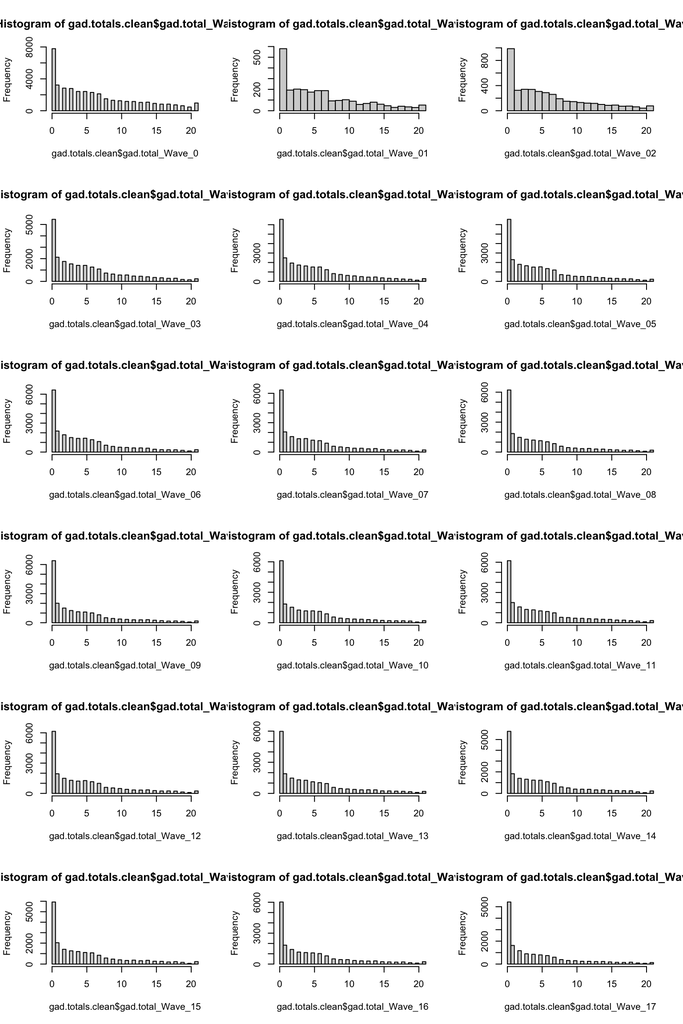

```r
layout(matrix(c(1:18), nrow=6, byrow=T))

hist(gad.totals.clean$gad.total_Wave_0, breaks="FD")
hist(gad.totals.clean$gad.total_Wave_01, breaks="FD")
hist(gad.totals.clean$gad.total_Wave_02, breaks="FD")

hist(gad.totals.clean$gad.total_Wave_03, breaks="FD")
hist(gad.totals.clean$gad.total_Wave_04, breaks="FD")
hist(gad.totals.clean$gad.total_Wave_05, breaks="FD")

hist(gad.totals.clean$gad.total_Wave_06, breaks="FD")
hist(gad.totals.clean$gad.total_Wave_07, breaks="FD")
hist(gad.totals.clean$gad.total_Wave_08, breaks="FD")

hist(gad.totals.clean$gad.total_Wave_09, breaks="FD")
hist(gad.totals.clean$gad.total_Wave_10, breaks="FD")
hist(gad.totals.clean$gad.total_Wave_11, breaks="FD")

hist(gad.totals.clean$gad.total_Wave_12, breaks="FD")
hist(gad.totals.clean$gad.total_Wave_13, breaks="FD")
hist(gad.totals.clean$gad.total_Wave_14, breaks="FD")

hist(gad.totals.clean$gad.total_Wave_15, breaks="FD")
hist(gad.totals.clean$gad.total_Wave_16, breaks="FD")
hist(gad.totals.clean$gad.total_Wave_17, breaks="FD")
```

```r
layout(1)
```